# Dementia

[figure not shown]

##### Made by : Marjolein van der Eerden

## Table of contents

1. Proposal

1.1. Domain understanding

1.2. Data sourcing

1.3. Analytic approach

2. Provisioning

2.1. Data requirements

2.2. Data collection

2.3. Data understanding

2.4. Data preparation

3. Predictions KNN

3.1. Preprocessing KNN

3.2. Modeling KNN

3.3. Evaluation KNN

2. Provisioning

2.3. Data understanding

2.4. Data preparation

3. Predictions Decision tree

3.1. Preprocessing Decision tree

3.2. Modeling Decision tree

3.3. Evaluation Decision tree

3.1. Preprocessing Decision tree 2

3.2. Modeling Decision tree 2

3.3. Evaluation Decision tree 2

2. Provisioning

2.3. Data understanding

2.4. Data preparation

3. Predictions Random forest

3.1. Preprocessing Random forest

3.2. Modeling Random forest

3.3. Evaluation Random forest

3.1. Preprocessing Random forest 2

3.2. Modeling Random forest 2

3.3. Evaluation Random forest 2

4. Conclusion

## Proposal

Proposal

✅ What?

I am going to predict if a person has dementia based on the correlations between features in the data set.

✅ Why?

Dementia is a debilitating disease that causes someone to lose memories and everything that makes them who they are. Catching this disease early gives the family extra time with the loved one while they are still stable.

✅ Who?

This project has multiple stake holders.

```
the patient.
the relatives of the patient.
the doctors.
```

✅ When?

This project has to be completed before the end of week 12.

✅ How?

To complete this challenge successfully I need a dataset that contains the needed information to predict wether or not someone has dementia. and I need the knowledge to complete each phase of the AI Project Methodology.

### Domain understanding

#### What is dementia?

Dementia is a term for a wide variety of specific medical conditions, the main symptoms of dementia are loss of memory, language, problem-solving and other thinking abilities severe enough to interfere with daily life.

[figure not shown]

In the picture above you can see some of the most common conditions that cause dementia.

Medical conditions ordered under the term dementia is caused by damaged brain cells, this damage causes that they can communicate with each other properly. These changes can trigger a decline in cognitive abilities (thinking skills), they also affect behavior, feelings, and relationships. Alzheimer’s accounts for the majority of the cases.

Most of the conditions that cause dementia, start slowly and gradually gets worse. When someone is experiencing memory difficulties or other changes in thinking abilities, it is important to see a doctor. An early diagnosis allows a patient to get the most benefit of the treatment, or even cured when it is a treatable condition.

> What is Dementia? (z.d.). Alzheimer’s Disease and Dementia. https://www.alz.org/alzheimers-dementia/what-is-dementia

#### What increases the changes of getting dementia?

Dementia affects mainly older people but not everyone will get it. There are things that increase the risk of developing dementia, such as:

- Age
- Diabetes
- High blood pressure
- Overweight
- Smoking and drinking
- Being physically inactive
- Being socially isolated
- Depression

Dementia is a syndrome that can be caused by a variety of diseases that destroy nerve cells and damage the brain. Typically, this results in the loss of the ability to process thought, more than what is expected from aging normally.

> World Health Organization: WHO & World Health Organization: WHO. (2023). Dementia. www.who.int. https://www.who.int/news-room/fact-sheets/detail/dementia

#### Difference between men and women

Women of 80 years old have about a 50% higher chance of getting dementia then men. Before 80 years old the risk levels are about the same.

The menopause is a key distinction between elderly men and women. Estrogen and progesterone levels fall sharply at this time in women who are in their late middle years.

Estrogen may be able to inhibit some of the negative effects of some of the chemicals linked to Alzheimer's disease, among other protective effects on brain health.

This has prompted some researchers to hypothesize that a person may be less prone to develop dementia if they are exposed to estrogen more frequently during their lifetime.

https://www.alzheimers.org.uk/blog/why-dementia-different-women#:~:text=Women%20have%20a%20greater%20risk,risk%20factor%20for%20this%20disease.

#### How does dementia get diagnosed?

There isn't a test that says someone has dementia. It is more a combination of cognitive and neurological test with what doctors can fairly accurately say that someone has dementia. The hard part is finding what type of dementia someone has.

> What is Dementia? (z.d.). Alzheimer’s Disease and Dementia. https://www.alz.org/alzheimers-dementia/what-is-dementia

Patients now have to wait about an average of 20 months before they get the right diagnoses. Although the symptoms of different forms of dementia don't differ a lot in early stages of the disease. Yet different care path ways or disease modifying medications are needed. Brain imaging can have a impact on the time a patient has to wait before getting th right diagnosis, and even give a greater certainty on what type of dementia the patient has.

> Using MRI scans to reveal early signs of dementia | Health-RI. (2019, 6 maart). Health-RI. https://www.health-ri.nl/news/using-mri-scans-reveal-early-signs-dementia

#### How can MRI's improve diagnosis?

Even though MRI's already play a big part in the diagnosis of dementia, it is difficult to catch early stage brain abnormalities with the naked eye. Together with Wiro Niessen, a professor of biomedical image analysis at Erasmus MC and a researcher in medical image processing at TU Delft, Vernooij and her team made a computer program that gives doctors a clearer view of brain abnormalities that might indicate early stage dementia.

Their software analyses the potential volume of shrinking brain regions and evaluates the degree to which the various brain regions are still communicating with one another. A challenge in this software is distinguishing normal shrinking of the brain due to aging from that from a brain disorder.

> Using MRI scans to reveal early signs of dementia | Health-RI. (2019, 6 maart). Health-RI. https://www.health-ri.nl/news/using-mri-scans-reveal-early-signs-dementia

#### What happens after diagnosis?

There is no cure for dementia. Treatment for dementia is mostly build on keeping the patient active and simulating the brain to maintain daily functions. Besides that there might be some medications to prevent further damage to the brain for example for vascular dementia.

But what can actually be done in early stages of dementia? The longer you have you diagnosis the harder it is going to be to make choices for yourself or financially. That is why it is important to think ahead.

- Choose people you trust and aks them to support you with making choices, and help you communicate them.
- create a plan and tell people what your choices for care and support are.
- reach out to family and friends and tell them how they can help you.

Caring for someone living with dementia is challenging and impacting a cares life and wel being.

> World Health Organization: WHO & World Health Organization: WHO. (2023). Dementia. www.who.int. https://www.who.int/news-room/fact-sheets/detail/dementia

### Data sourcing

For the dataset to be considered usable it will need to have the following characteristics:

- Demographic information like age, gender, and social class
- Measures of cognitive functions like memory, attention, language, and executive function.
- Imaging testing can show brain abnormalities. I could not find any related brain scans for my current dataset.
- Dementia diagnosis.

The OASIS dataset contains these characteristics making it a good match for this project.

This set consists of a longitudinal collection of 150 subjects aged 60 to 96. Each subject was scanned on two or more visits, separated by at least one year for a total of 373 imaging sessions. For each subject, 3 or 4 individual T1-weighted MRI scans obtained in single scan sessions are included. The subjects are all right-handed and include both men and women. 72 of the subjects were characterized as non-demented throughout the study. 64 of the included subjects were characterized as demented at the time of their initial visits and remained so for subsequent scans, including 51 individuals with mild to moderate Alzheimer’s disease. Another 14 subjects were characterized as non-demented at the time of their initial visit and were subsequently characterized as demented at a later visit.

The dataset originates from Washington University, a big university with a good reputation in regards to their research in the medical field. This data was collected by Drs. Morris and Benzinger from Washington University with the intended purpose of making the dat available for the public, so that it can be used in studies and research by others.

> Dementia Prediction Dataset. (2021, 8 augustus). Kaggle. https://www.kaggle.com/datasets/shashwatwork/dementia-prediction-dataset

> Marcus, D. S., Fotenos, A. F., Csernansky, J. G., Morris, J. C., & Buckner, R. L. (2010). Open Access Series of Imaging Studies: Longitudinal MRI Data in Nondemented and Demented Older Adults. Journal of Cognitive Neuroscience, 22(12), 2677–2684. https://doi.org/10.1162/jocn.2009.21407

> OASIS Brains - Open Access Series of Imaging Studies. (z.d.). https://www.oasis-brains.org/

### Analytic approach

The target variable for this project will be the Group. I started off by looking at it like it is a classification problem. Afterward, I decided to look at it as if it is a regression problem since it has 3 groups where one has aspects from the other 2 groups.

## Provisioning

### Data requirements

To predict dementia, it can be helpful to have:

- Demographic information like:
  - age: Older people have a much higher chance of getting Alzheimer Disease, making this an important factor.
  - gender: Elderly women have a higher chance of developing Alzheimer Disease than men.
  - social class: I think that social class could be a factor that increases the risk of Alzheimer Disease. This is because people with less money to spend are less active and have a higher chance of being overweight.
- Medical history could also be helpful but won't be used in this challenge since it is not found on the internet due to privacy reasons.
- Family history could also give a good insight into whether someone is likely to develop dementia. However, the same as with medical history it is not found on the internet and will therefore not used in this challenge.
- Measures of cognitive functions like
  - memory: One of the most commonly known symptom of Alzheimer Disease is memory loss, making this a key factor in diagnosing the disease.
  - Executive function: During the progression of Alzheimer Disease a patient will lose the ability of preforming everyday tasks.
- Imaging testing can show brain abnormalities: On MRI and other brain imaging scans you can see the deterioration of the brain caused by Alzheimer.
- Blood tests that can show biomarkers for dementia: Alzheimer Disease has a specific bio marker that can be found in the blood of the patient that indicates a high risk of Alzheimer.

### Data collection

Data collection is the process of gathering the data that will be used tor train and / or test the AI model.

I started this part of by importing the needed packages.

```python
# importing the needed packages
import pandas
import seaborn
import numpy
import matplotlib.pyplot as plt
import math
```

After I got the packages that I need. It is time for loading the dataset.

```python
#reading the CSV file.
df = pandas.read_csv('dementia_dataset.csv')
df
```

[output not shown]

|  | Subject ID | MRI ID | Group | Visit | MR Delay | M/F | Hand | Age | EDUC | SES | MMSE | CDR | eTIV | nWBV | ASF |
| --- | --- | --- | --- | --- | --- | --- | --- | --- | --- | --- | --- | --- | --- | --- | --- |
| 0 | OAS2_0001 | OAS2_0001_MR1 | Nondemented | 1 | 0 | M | R | 87 | 14 | 2.0 | 27.0 | 0.0 | 1987 | 0.696 | 0.883 |
| 1 | OAS2_0001 | OAS2_0001_MR2 | Nondemented | 2 | 457 | M | R | 88 | 14 | 2.0 | 30.0 | 0.0 | 2004 | 0.681 | 0.876 |
| 2 | OAS2_0002 | OAS2_0002_MR1 | Demented | 1 | 0 | M | R | 75 | 12 | NaN | 23.0 | 0.5 | 1678 | 0.736 | 1.046 |
| 3 | OAS2_0002 | OAS2_0002_MR2 | Demented | 2 | 560 | M | R | 76 | 12 | NaN | 28.0 | 0.5 | 1738 | 0.713 | 1.010 |
| 4 | OAS2_0002 | OAS2_0002_MR3 | Demented | 3 | 1895 | M | R | 80 | 12 | NaN | 22.0 | 0.5 | 1698 | 0.701 | 1.034 |
| ... | ... | ... | ... | ... | ... | ... | ... | ... | ... | ... | ... | ... | ... | ... | ... |
| 368 | OAS2_0185 | OAS2_0185_MR2 | Demented | 2 | 842 | M | R | 82 | 16 | 1.0 | 28.0 | 0.5 | 1693 | 0.694 | 1.037 |
| 369 | OAS2_0185 | OAS2_0185_MR3 | Demented | 3 | 2297 | M | R | 86 | 16 | 1.0 | 26.0 | 0.5 | 1688 | 0.675 | 1.040 |
| 370 | OAS2_0186 | OAS2_0186_MR1 | Nondemented | 1 | 0 | F | R | 61 | 13 | 2.0 | 30.0 | 0.0 | 1319 | 0.801 | 1.331 |
| 371 | OAS2_0186 | OAS2_0186_MR2 | Nondemented | 2 | 763 | F | R | 63 | 13 | 2.0 | 30.0 | 0.0 | 1327 | 0.796 | 1.323 |
| 372 | OAS2_0186 | OAS2_0186_MR3 | Nondemented | 3 | 1608 | F | R | 65 | 13 | 2.0 | 30.0 | 0.0 | 1333 | 0.801 | 1.317 |

373 rows × 15 columns

Now that I see a sample of the data I can start understanding what each column means.

##### Data dictionary.

- Subject ID = patient id this is not a unique value
- MRI ID = is the id of the MRI is a unique value(`after some data understanding i found that this variable is a combination of subject id and visit`)
- Group = whether they are demented, converted or non-demented(`The Convert column indicates individuals who were determined to have Alzheimer's disease on a subsequent visit. CDR = Clinical Dementia Rating, with 0, 0.5, and 1 corresponding to non-demented, very mild, and Alzheimer's disease, respectively. CDR 0.5 individuals may be considered to represent those elsewhere labeled as “mild cognitive impairment” (MCI).`)
- Visit = the number of the visit
- **MR Delay = am still not sure what this exactly is**
- M/F = `Sex (M or F)`
- Hand = whether they are left or right
- Age = the age of the patient `Age at time of image acquisition (years)`
- EDUC = `Years of education`
- SES = Social Economic Status `Socioeconomic status as assessed by the Hollingshead Index of Social Position and classified into categories from 1 (highest status) to 5 (lowest status) (Hollingshead, 1957)`
- MMSE = The mini mental state examination (`score (range is from 0 = worst to 30 = best) (Folstein, Folstein, & McHugh, 1975)`)
- CDR = Clinical Dementia Rating `(0 = no dementia, 0.5 = very mild AD, 1 = mild AD, 2 = moderate AD) (Morris, 1993)`(AD= alzheimer disease)
- eTIV = estimated Total Intracranial Volume(`Estimated total intracranial volume (cm3) (Buckner et al., 2004)`)
- nWBV = normalized Whole Brain Volume(`Normalized whole-brain volume, expressed as a percent of all voxels in the atlas-masked image that are labeled as gray or white matter by the automated tissue segmentation process (Fotenos et al., 2005)`)
- ASF = Atlas Scaling Factor(`Atlas scaling factor (unit less). Computed scaling factor that transforms native-space brain and skull to the atlas target (i.e., the determinant of the transform matrix) (Buckner et al., 2004)`)

> Mittal, M., Chintalapudi, N., & Amenta, F. (2019). Machine learning in medicine: Performance calculation of dementia prediction by support vector machines (SVM). Informatics in Medicine Unlocked, 16, 100200. https://doi.org/10.1016/j.imu.2019.100200

> Marcus, D. S., Fotenos, A. F., Csernansky, J. G., Morris, J. C., & Buckner, R. L. (2010). Open Access Series of Imaging Studies: Longitudinal MRI Data in Nondemented and Demented Older Adults. Journal of Cognitive Neuroscience, 22(12), 2677–2684. https://doi.org/10.1162/jocn.2009.21407

The data is recorder in a csv file by Washington University. It contains 150 patient who had at least 2 MRI scans separated by 1 year. It is a locally stored file in csv format. This data can be found [here](https://doi.org/10.1162/jocn.2009.21407).

### Data understanding

Data understanding is a critical step in the data science process that involves exploring, visualizing, and summarizing data to gain insights and identify patterns or anomalies. It is the foundation for the next phase modeling. It helps to understand the data your working with.

I divided Phase 2 in multiple headers(anomalies, missing values, preparation, and visualisations) so that you can clearly find everything under the fitting header.

#### Anomalies

```python
# looking at the data information
df.info()
```

```
<class 'pandas.core.frame.DataFrame'>
RangeIndex: 373 entries, 0 to 372
Data columns (total 15 columns):
 #   Column      Non-Null Count  Dtype
---  ------      --------------  -----
 0   Subject ID  373 non-null    object
 1   MRI ID      373 non-null    object
 2   Group       373 non-null    object
 3   Visit       373 non-null    int64
 4   MR Delay    373 non-null    int64
 5   M/F         373 non-null    object
 6   Hand        373 non-null    object
 7   Age         373 non-null    int64
 8   EDUC        373 non-null    int64
 9   SES         354 non-null    float64
 10  MMSE        371 non-null    float64
 11  CDR         373 non-null    float64
 12  eTIV        373 non-null    int64
 13  nWBV        373 non-null    float64
 14  ASF         373 non-null    float64
dtypes: float64(5), int64(5), object(5)
memory usage: 43.8+ KB
```

Looking at the information above I notice that the Subject ID and MRI ID are objects type while logic would say it should be numeric. So for the next two steps I will be looking closer to these two columns.

```python
# looking at all the unique subjects ideas
df['Subject ID'].unique()
```

```
array(['OAS2_0001', 'OAS2_0002', 'OAS2_0004', 'OAS2_0005', 'OAS2_0007',
       'OAS2_0008', 'OAS2_0009', 'OAS2_0010', 'OAS2_0012', 'OAS2_0013',
       'OAS2_0014', 'OAS2_0016', 'OAS2_0017', 'OAS2_0018', 'OAS2_0020',
       'OAS2_0021', 'OAS2_0022', 'OAS2_0023', 'OAS2_0026', 'OAS2_0027',
       'OAS2_0028', 'OAS2_0029', 'OAS2_0030', 'OAS2_0031', 'OAS2_0032',
       'OAS2_0034', 'OAS2_0035', 'OAS2_0036', 'OAS2_0037', 'OAS2_0039',
       'OAS2_0040', 'OAS2_0041', 'OAS2_0042', 'OAS2_0043', 'OAS2_0044',
       'OAS2_0045', 'OAS2_0046', 'OAS2_0047', 'OAS2_0048', 'OAS2_0049',
       'OAS2_0050', 'OAS2_0051', 'OAS2_0052', 'OAS2_0053', 'OAS2_0054',
       'OAS2_0055', 'OAS2_0056', 'OAS2_0057', 'OAS2_0058', 'OAS2_0060',
       'OAS2_0061', 'OAS2_0062', 'OAS2_0063', 'OAS2_0064', 'OAS2_0066',
       'OAS2_0067', 'OAS2_0068', 'OAS2_0069', 'OAS2_0070', 'OAS2_0071',
       'OAS2_0073', 'OAS2_0075', 'OAS2_0076', 'OAS2_0077', 'OAS2_0078',
       'OAS2_0079', 'OAS2_0080', 'OAS2_0081', 'OAS2_0085', 'OAS2_0086',
       'OAS2_0087', 'OAS2_0088', 'OAS2_0089', 'OAS2_0090', 'OAS2_0091',
       'OAS2_0092', 'OAS2_0094', 'OAS2_0095', 'OAS2_0096', 'OAS2_0097',
       'OAS2_0098', 'OAS2_0099', 'OAS2_0100', 'OAS2_0101', 'OAS2_0102',
       'OAS2_0103', 'OAS2_0104', 'OAS2_0105', 'OAS2_0106', 'OAS2_0108',
       'OAS2_0109', 'OAS2_0111', 'OAS2_0112', 'OAS2_0113', 'OAS2_0114',
       'OAS2_0116', 'OAS2_0117', 'OAS2_0118', 'OAS2_0119', 'OAS2_0120',
       'OAS2_0121', 'OAS2_0122', 'OAS2_0124', 'OAS2_0126', 'OAS2_0127',
       'OAS2_0128', 'OAS2_0129', 'OAS2_0131', 'OAS2_0133', 'OAS2_0134',
       'OAS2_0135', 'OAS2_0137', 'OAS2_0138', 'OAS2_0139', 'OAS2_0140',
       'OAS2_0141', 'OAS2_0142', 'OAS2_0143', 'OAS2_0144', 'OAS2_0145',
       'OAS2_0146', 'OAS2_0147', 'OAS2_0149', 'OAS2_0150', 'OAS2_0152',
       'OAS2_0154', 'OAS2_0156', 'OAS2_0157', 'OAS2_0158', 'OAS2_0159',
       'OAS2_0160', 'OAS2_0161', 'OAS2_0162', 'OAS2_0164', 'OAS2_0165',
       'OAS2_0169', 'OAS2_0171', 'OAS2_0172', 'OAS2_0174', 'OAS2_0175',
       'OAS2_0176', 'OAS2_0177', 'OAS2_0178', 'OAS2_0179', 'OAS2_0181',
       'OAS2_0182', 'OAS2_0183', 'OAS2_0184', 'OAS2_0185', 'OAS2_0186'],
      dtype=object)
```

The letter used in the column of the subject ID does not seem to have any added value, because all the unique IDs start the same with (OAS2_). So, I think it is safe to say these can be removed.

Next I checked how many distinct variables were in the subject ID column.

```python
# count the number of unique variables in the Subject ID column
df['Subject ID'].nunique()
```

```
150
```

At this moment there are 150 unique values in the subject ID column. This corresponds with the 150 patients they followed during this research.

Just like I did with the Subject ID I will now look at why MRI ID is not the expected numerical type. I do that by first getting an overview of each distinct value.

```python
# looking at all the unique MRI ID's
df['MRI ID'].unique()
```

```
array(['OAS2_0001_MR1', 'OAS2_0001_MR2', 'OAS2_0002_MR1', 'OAS2_0002_MR2',
       'OAS2_0002_MR3', 'OAS2_0004_MR1', 'OAS2_0004_MR2', 'OAS2_0005_MR1',
       'OAS2_0005_MR2', 'OAS2_0005_MR3', 'OAS2_0007_MR1', 'OAS2_0007_MR3',
       'OAS2_0007_MR4', 'OAS2_0008_MR1', 'OAS2_0008_MR2', 'OAS2_0009_MR1',
       'OAS2_0009_MR2', 'OAS2_0010_MR1', 'OAS2_0010_MR2', 'OAS2_0012_MR1',
       'OAS2_0012_MR2', 'OAS2_0012_MR3', 'OAS2_0013_MR1', 'OAS2_0013_MR2',
       'OAS2_0013_MR3', 'OAS2_0014_MR1', 'OAS2_0014_MR2', 'OAS2_0016_MR1',
       'OAS2_0016_MR2', 'OAS2_0017_MR1', 'OAS2_0017_MR3', 'OAS2_0017_MR4',
       'OAS2_0017_MR5', 'OAS2_0018_MR1', 'OAS2_0018_MR3', 'OAS2_0018_MR4',
       'OAS2_0020_MR1', 'OAS2_0020_MR2', 'OAS2_0020_MR3', 'OAS2_0021_MR1',
       'OAS2_0021_MR2', 'OAS2_0022_MR1', 'OAS2_0022_MR2', 'OAS2_0023_MR1',
       'OAS2_0023_MR2', 'OAS2_0026_MR1', 'OAS2_0026_MR2', 'OAS2_0027_MR1',
       'OAS2_0027_MR2', 'OAS2_0027_MR3', 'OAS2_0027_MR4', 'OAS2_0028_MR1',
       'OAS2_0028_MR2', 'OAS2_0029_MR1', 'OAS2_0029_MR2', 'OAS2_0030_MR1',
       'OAS2_0030_MR2', 'OAS2_0031_MR1', 'OAS2_0031_MR2', 'OAS2_0031_MR3',
       'OAS2_0032_MR1', 'OAS2_0032_MR2', 'OAS2_0034_MR1', 'OAS2_0034_MR2',
       'OAS2_0034_MR3', 'OAS2_0034_MR4', 'OAS2_0035_MR1', 'OAS2_0035_MR2',
       'OAS2_0036_MR1', 'OAS2_0036_MR3', 'OAS2_0036_MR4', 'OAS2_0036_MR5',
       'OAS2_0037_MR1', 'OAS2_0037_MR2', 'OAS2_0037_MR3', 'OAS2_0037_MR4',
       'OAS2_0039_MR1', 'OAS2_0039_MR2', 'OAS2_0040_MR1', 'OAS2_0040_MR2',
       'OAS2_0040_MR3', 'OAS2_0041_MR1', 'OAS2_0041_MR2', 'OAS2_0041_MR3',
       'OAS2_0042_MR1', 'OAS2_0042_MR2', 'OAS2_0043_MR1', 'OAS2_0043_MR2',
       'OAS2_0044_MR1', 'OAS2_0044_MR2', 'OAS2_0044_MR3', 'OAS2_0045_MR1',
       'OAS2_0045_MR2', 'OAS2_0046_MR1', 'OAS2_0046_MR2', 'OAS2_0047_MR1',
       'OAS2_0047_MR2', 'OAS2_0048_MR1', 'OAS2_0048_MR2', 'OAS2_0048_MR3',
       'OAS2_0048_MR4', 'OAS2_0048_MR5', 'OAS2_0049_MR1', 'OAS2_0049_MR2',
       'OAS2_0049_MR3', 'OAS2_0050_MR1', 'OAS2_0050_MR2', 'OAS2_0051_MR1',
       'OAS2_0051_MR2', 'OAS2_0051_MR3', 'OAS2_0052_MR1', 'OAS2_0052_MR2',
       'OAS2_0053_MR1', 'OAS2_0053_MR2', 'OAS2_0054_MR1', 'OAS2_0054_MR2',
       'OAS2_0055_MR1', 'OAS2_0055_MR2', 'OAS2_0056_MR1', 'OAS2_0056_MR2',
       'OAS2_0057_MR1', 'OAS2_0057_MR2', 'OAS2_0057_MR3', 'OAS2_0058_MR1',
       'OAS2_0058_MR2', 'OAS2_0058_MR3', 'OAS2_0060_MR1', 'OAS2_0060_MR2',
       'OAS2_0061_MR1', 'OAS2_0061_MR2', 'OAS2_0061_MR3', 'OAS2_0062_MR1',
       'OAS2_0062_MR2', 'OAS2_0062_MR3', 'OAS2_0063_MR1', 'OAS2_0063_MR2',
       'OAS2_0064_MR1', 'OAS2_0064_MR2', 'OAS2_0064_MR3', 'OAS2_0066_MR1',
       'OAS2_0066_MR2', 'OAS2_0067_MR1', 'OAS2_0067_MR2', 'OAS2_0067_MR3',
       'OAS2_0067_MR4', 'OAS2_0068_MR1', 'OAS2_0068_MR2', 'OAS2_0069_MR1',
       'OAS2_0069_MR2', 'OAS2_0070_MR1', 'OAS2_0070_MR2', 'OAS2_0070_MR3',
       'OAS2_0070_MR4', 'OAS2_0070_MR5', 'OAS2_0071_MR1', 'OAS2_0071_MR2',
       'OAS2_0073_MR1', 'OAS2_0073_MR2', 'OAS2_0073_MR3', 'OAS2_0073_MR4',
```

[output cut: 39 more lines]

```
       'OAS2_0157_MR1', 'OAS2_0157_MR2', 'OAS2_0158_MR1', 'OAS2_0158_MR2',
       'OAS2_0159_MR1', 'OAS2_0159_MR2', 'OAS2_0160_MR1', 'OAS2_0160_MR2',
       'OAS2_0161_MR1', 'OAS2_0161_MR2', 'OAS2_0161_MR3', 'OAS2_0162_MR1',
       'OAS2_0162_MR2', 'OAS2_0164_MR1', 'OAS2_0164_MR2', 'OAS2_0165_MR1',
       'OAS2_0165_MR2', 'OAS2_0169_MR1', 'OAS2_0169_MR2', 'OAS2_0171_MR1',
       'OAS2_0171_MR2', 'OAS2_0171_MR3', 'OAS2_0172_MR1', 'OAS2_0172_MR2',
       'OAS2_0174_MR1', 'OAS2_0174_MR2', 'OAS2_0174_MR3', 'OAS2_0175_MR1',
       'OAS2_0175_MR2', 'OAS2_0175_MR3', 'OAS2_0176_MR1', 'OAS2_0176_MR2',
       'OAS2_0176_MR3', 'OAS2_0177_MR1', 'OAS2_0177_MR2', 'OAS2_0178_MR1',
       'OAS2_0178_MR2', 'OAS2_0178_MR3', 'OAS2_0179_MR1', 'OAS2_0179_MR2',
       'OAS2_0181_MR1', 'OAS2_0181_MR2', 'OAS2_0181_MR3', 'OAS2_0182_MR1',
       'OAS2_0182_MR2', 'OAS2_0183_MR1', 'OAS2_0183_MR2', 'OAS2_0183_MR3',
       'OAS2_0183_MR4', 'OAS2_0184_MR1', 'OAS2_0184_MR2', 'OAS2_0185_MR1',
       'OAS2_0185_MR2', 'OAS2_0185_MR3', 'OAS2_0186_MR1', 'OAS2_0186_MR2',
       'OAS2_0186_MR3'], dtype=object)
```

What I notice about the MRI ID is that it seems to be the subject ID with their MRI number. I think I can remove the subject ID. However, I don’t yet know how I am going to tackle the MRI number behind it. So I will be looking closer at it in the next iteration.

I then decided to look at what different kinds of groups I have in the target variable, to see if it needs any modifications.

```python
# looking at all the unique groups
df['Group'].unique()
```

```
array(['Nondemented', 'Demented', 'Converted'], dtype=object)
```

As printed above there are 3 different groups Demented (people who have dementia), Non-demented(people who do not have dementia) and Converted(people who I determined to have dementia at a subsequent visit).

##### Missing values

In this next part I am going to look for missing values and how to deal with them. I started this of with counting the missing values in each column.

```python
# Check for missing values in the dataframe
df.isnull().sum()
```

```
Subject ID     0
MRI ID         0
Group          0
Visit          0
MR Delay       0
M/F            0
Hand           0
Age            0
EDUC           0
SES           19
MMSE           2
CDR            0
eTIV           0
nWBV           0
ASF            0
dtype: int64
```

As seen above there are 19 missing values in the SES(social economical status) column, and 2 missing values in the MMSE(Mini mental state examination) column. Next I am going to see why they could be missing, I do this by zooming in on the missing values in the SES column.

The missing values in this column could be because:

- The patient did not want to disclose that information.
- There went something wrong with the recording of this information. (for example it is only recorded for 1 visit)

To figure out why this is happening I need to look closer at the column.

```python
# Select rows in the DataFrame where the value in the SES column is null
df[df.SES.isnull()]
```

|  | Subject ID | MRI ID | Group | Visit | MR Delay | M/F | Hand | Age | EDUC | SES | MMSE | CDR | eTIV | nWBV | ASF |
| --- | --- | --- | --- | --- | --- | --- | --- | --- | --- | --- | --- | --- | --- | --- | --- |
| 2 | OAS2_0002 | OAS2_0002_MR1 | Demented | 1 | 0 | M | R | 75 | 12 | NaN | 23.0 | 0.5 | 1678 | 0.736 | 1.046 |
| 3 | OAS2_0002 | OAS2_0002_MR2 | Demented | 2 | 560 | M | R | 76 | 12 | NaN | 28.0 | 0.5 | 1738 | 0.713 | 1.010 |
| 4 | OAS2_0002 | OAS2_0002_MR3 | Demented | 3 | 1895 | M | R | 80 | 12 | NaN | 22.0 | 0.5 | 1698 | 0.701 | 1.034 |
| 10 | OAS2_0007 | OAS2_0007_MR1 | Demented | 1 | 0 | M | R | 71 | 16 | NaN | 28.0 | 0.5 | 1357 | 0.748 | 1.293 |
| 11 | OAS2_0007 | OAS2_0007_MR3 | Demented | 3 | 518 | M | R | 73 | 16 | NaN | 27.0 | 1.0 | 1365 | 0.727 | 1.286 |
| 12 | OAS2_0007 | OAS2_0007_MR4 | Demented | 4 | 1281 | M | R | 75 | 16 | NaN | 27.0 | 1.0 | 1372 | 0.710 | 1.279 |
| 134 | OAS2_0063 | OAS2_0063_MR1 | Demented | 1 | 0 | F | R | 80 | 12 | NaN | 30.0 | 0.5 | 1430 | 0.737 | 1.228 |
| 135 | OAS2_0063 | OAS2_0063_MR2 | Demented | 2 | 490 | F | R | 81 | 12 | NaN | 27.0 | 0.5 | 1453 | 0.721 | 1.208 |
| 207 | OAS2_0099 | OAS2_0099_MR1 | Demented | 1 | 0 | F | R | 80 | 12 | NaN | 27.0 | 0.5 | 1475 | 0.762 | 1.190 |
| 208 | OAS2_0099 | OAS2_0099_MR2 | Demented | 2 | 807 | F | R | 83 | 12 | NaN | 23.0 | 0.5 | 1484 | 0.750 | 1.183 |
| 237 | OAS2_0114 | OAS2_0114_MR1 | Demented | 1 | 0 | F | R | 76 | 12 | NaN | 27.0 | 0.5 | 1316 | 0.727 | 1.333 |
| 238 | OAS2_0114 | OAS2_0114_MR2 | Demented | 2 | 570 | F | R | 78 | 12 | NaN | 27.0 | 1.0 | 1309 | 0.709 | 1.341 |
| 322 | OAS2_0160 | OAS2_0160_MR1 | Demented | 1 | 0 | M | R | 76 | 12 | NaN | 27.0 | 0.5 | 1557 | 0.705 | 1.127 |
| 323 | OAS2_0160 | OAS2_0160_MR2 | Demented | 2 | 552 | M | R | 78 | 12 | NaN | 29.0 | 1.0 | 1569 | 0.704 | 1.119 |
| 356 | OAS2_0181 | OAS2_0181_MR1 | Demented | 1 | 0 | F | R | 74 | 12 | NaN | 26.0 | 0.5 | 1171 | 0.733 | 1.499 |
| 357 | OAS2_0181 | OAS2_0181_MR2 | Demented | 2 | 539 | F | R | 75 | 12 | NaN | NaN | 1.0 | 1169 | 0.742 | 1.501 |
| 358 | OAS2_0181 | OAS2_0181_MR3 | Demented | 3 | 1107 | F | R | 77 | 12 | NaN | NaN | 1.0 | 1159 | 0.733 | 1.515 |
| 359 | OAS2_0182 | OAS2_0182_MR1 | Demented | 1 | 0 | M | R | 73 | 12 | NaN | 23.0 | 0.5 | 1661 | 0.698 | 1.056 |
| 360 | OAS2_0182 | OAS2_0182_MR2 | Demented | 2 | 776 | M | R | 75 | 12 | NaN | 20.0 | 0.5 | 1654 | 0.696 | 1.061 |

After I zoomed in on the missing values in the SES column I saw that the patients all had a education of 12 years or higher. There might be a way to fill them using the EDUC column. I also saw that the two missing values for the MMSE column were for a patient that also had missing values in SES column.

Since the missing values were for Patients with 12 years of education and one with 16 years of education I made a graph to see if I can fill in the NaN in the SES column.

The first graph shows the distribution of the Social economical status for people who had 12 years of education.

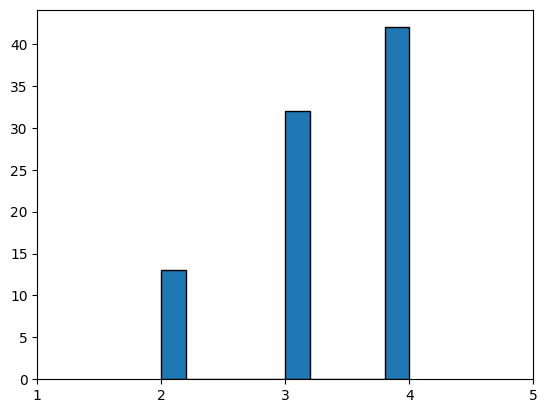

```python
# filtering the patient who has 12 years of education
df1 = df[(df['EDUC']== 12)]

# making a histogram for SES column
plt.hist(df1['SES'], edgecolor='k')

# set the x-axis ticks to integers only
plt.xticks(range(1, 6))

# display the histogram
plt.show()
```

Next I did the same thing with people who had 16 years of education.

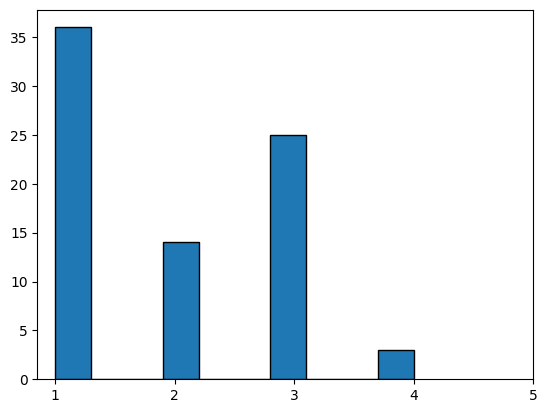

```python
# filtering the patient who has 16 years of education
df1 = df[(df['EDUC']== 16)]

# making a histogram for SES column
plt.hist(df1['SES'], edgecolor='k')

# set the x-axis ticks to integers only
plt.xticks(range(1, 6))

# display the histogram
plt.show()
```

From both of these graphs I can't conclude how to fill in the SES column, I see that one status peeks more but the difference is not significantly large enough to take that as the value for the SES column.

#### visualisations

After manipulating the data I started visualizing the data to see what the balance of my data set is. The first visualization that I made is a pie plot.

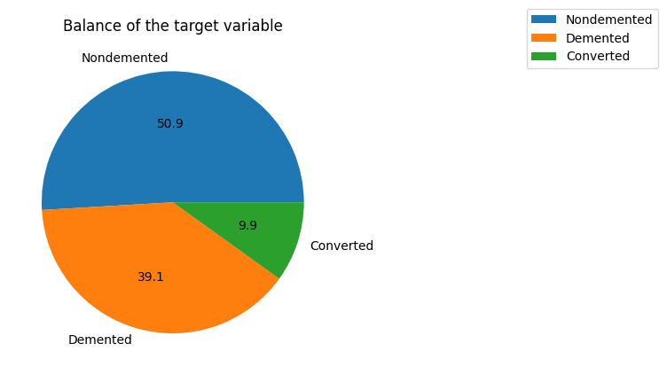

```python
# Create a new DataFrame with the count of each unique value in the 'Group' column of the original DataFrame
df1 = pandas.DataFrame(df['Group'].value_counts())

# Reset the index of the new DataFrame and rename the columns to 'Subject ID' and 'Total'
df1 = df1.reset_index()
df1.columns = ['Subject ID', 'Total']

# Create a pie chart of the 'Total' values, with the 'Subject ID' values as labels and the percentage values displayed
plt.pie(df1['Total'], labels=df1['Subject ID'], autopct='%.01f')

# Add a legend to the pie chart and adjust its position
plt.legend(bbox_to_anchor=(2,1), loc='center right')

# Set the title of the plot
plt.title("Balance of the target variable")

# Display the plot
plt.show()
```

In this pie plot you can see that the majority of the patient are not demented. 39.1 % of the patient are demented and 9.9% of the patient became demented during the research.

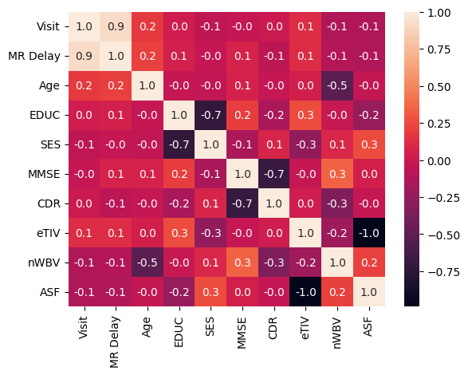

```python
correlations =df.corr()
plot = seaborn.heatmap(correlations, cbar=True, annot=True, fmt=".1f")
```

### Data preparation

Data preparation is the process of transforming raw data into a clean and structured format that is suitable for analysis. It is an essential step in data analysis as it helps to ensure that the data used for analysis is accurate, consistent, and complete. Data preparation involves several tasks such as data cleaning, data transformation, data integration, and data reduction.

I start with making the subject ID an numeric variable. I do this by Subsetting from the 5th character to the end.

```python
# Modify the 'Subject ID' column by removing the first 5 characters,
# converting the remaining string to an integer, and assigning it back to the column
df['Subject ID']= df["Subject ID"].str[5:].astype(int)
df
```

|  | Subject ID | MRI ID | Group | Visit | MR Delay | M/F | Hand | Age | EDUC | SES | MMSE | CDR | eTIV | nWBV | ASF |
| --- | --- | --- | --- | --- | --- | --- | --- | --- | --- | --- | --- | --- | --- | --- | --- |
| 0 | 1 | OAS2_0001_MR1 | Nondemented | 1 | 0 | M | R | 87 | 14 | 2.0 | 27.0 | 0.0 | 1987 | 0.696 | 0.883 |
| 1 | 1 | OAS2_0001_MR2 | Nondemented | 2 | 457 | M | R | 88 | 14 | 2.0 | 30.0 | 0.0 | 2004 | 0.681 | 0.876 |
| 2 | 2 | OAS2_0002_MR1 | Demented | 1 | 0 | M | R | 75 | 12 | NaN | 23.0 | 0.5 | 1678 | 0.736 | 1.046 |
| 3 | 2 | OAS2_0002_MR2 | Demented | 2 | 560 | M | R | 76 | 12 | NaN | 28.0 | 0.5 | 1738 | 0.713 | 1.010 |
| 4 | 2 | OAS2_0002_MR3 | Demented | 3 | 1895 | M | R | 80 | 12 | NaN | 22.0 | 0.5 | 1698 | 0.701 | 1.034 |
| ... | ... | ... | ... | ... | ... | ... | ... | ... | ... | ... | ... | ... | ... | ... | ... |
| 368 | 185 | OAS2_0185_MR2 | Demented | 2 | 842 | M | R | 82 | 16 | 1.0 | 28.0 | 0.5 | 1693 | 0.694 | 1.037 |
| 369 | 185 | OAS2_0185_MR3 | Demented | 3 | 2297 | M | R | 86 | 16 | 1.0 | 26.0 | 0.5 | 1688 | 0.675 | 1.040 |
| 370 | 186 | OAS2_0186_MR1 | Nondemented | 1 | 0 | F | R | 61 | 13 | 2.0 | 30.0 | 0.0 | 1319 | 0.801 | 1.331 |
| 371 | 186 | OAS2_0186_MR2 | Nondemented | 2 | 763 | F | R | 63 | 13 | 2.0 | 30.0 | 0.0 | 1327 | 0.796 | 1.323 |
| 372 | 186 | OAS2_0186_MR3 | Nondemented | 3 | 1608 | F | R | 65 | 13 | 2.0 | 30.0 | 0.0 | 1333 | 0.801 | 1.317 |

373 rows × 15 columns

Before I did any cleaning I had 150 unique values for subject ID. Here I am checking that again to see if I did not accidentally combine multiple Subject ID's.

```python
# checking if I didn't change the number of unique values.
df['Subject ID'].nunique()
```

```
150
```

I started doing the same for the MRI ID column. I however, commented it out because I realized something in the next iteration. (a more elaborate explanation will be given after my first model.)

```python
# # removing first 10 characters of the string
# df['MRI ID'] = df["MRI ID"].str[12:].astype(int)
# df
```

I then checked if the data type was changed to a integer using the info() function.

```python
# printing all the info for the dataframe
df.info()
```

```
<class 'pandas.core.frame.DataFrame'>
RangeIndex: 373 entries, 0 to 372
Data columns (total 15 columns):
 #   Column      Non-Null Count  Dtype
---  ------      --------------  -----
 0   Subject ID  373 non-null    int32
 1   MRI ID      373 non-null    object
 2   Group       373 non-null    object
 3   Visit       373 non-null    int64
 4   MR Delay    373 non-null    int64
 5   M/F         373 non-null    object
 6   Hand        373 non-null    object
 7   Age         373 non-null    int64
 8   EDUC        373 non-null    int64
 9   SES         354 non-null    float64
 10  MMSE        371 non-null    float64
 11  CDR         373 non-null    float64
 12  eTIV        373 non-null    int64
 13  nWBV        373 non-null    float64
 14  ASF         373 non-null    float64
dtypes: float64(5), int32(1), int64(5), object(4)
memory usage: 42.4+ KB
```

In conclusion, the datatype of the Subject ID column has been changed to numeric, this is a more optimized and makes it more easy to usa in the model.

## Predictions KNN

Modeling is the process of using algorithms to identify patterns in data and make predictions or decisions based on those patterns. The goal of modeling is to create a model that can accurately predict outcomes or classify data based on patterns in the input data.

I decided to start with a KNN classifier just to see what would happen when I used a classification model. I assumed a classification model would work best to start with because it were only 3 variables. I later came to a different conclusion.

### Preprocessing KNN

I started off by making sure my target variable is a numeric variable. I did this by using labelencoder() function.

```python
# Import the preprocessing module from scikit-learn
from sklearn import preprocessing

# Instantiate a LabelEncoder object
encoder = preprocessing.LabelEncoder()

# Use the fit_transform method to encode the "Group" column of the DataFrame
df["Group ID"] = encoder.fit_transform(df["Group"])

# Use the sample method to randomly select and display 10 rows from the DataFrame
df.sample(10)
```

|  | Subject ID | MRI ID | Group | Visit | MR Delay | M/F | Hand | Age | EDUC | SES | MMSE | CDR | eTIV | nWBV | ASF | Group ID |
| --- | --- | --- | --- | --- | --- | --- | --- | --- | --- | --- | --- | --- | --- | --- | --- | --- |
| 166 | 77 | OAS2_0077_MR1 | Nondemented | 1 | 0 | M | R | 69 | 16 | 2.0 | 28.0 | 0.0 | 1848 | 0.737 | 0.950 | 2 |
| 180 | 85 | OAS2_0085_MR2 | Nondemented | 2 | 670 | F | R | 80 | 8 | 5.0 | 27.0 | 0.0 | 1381 | 0.751 | 1.270 | 2 |
| 135 | 63 | OAS2_0063_MR2 | Demented | 2 | 490 | F | R | 81 | 12 | NaN | 27.0 | 0.5 | 1453 | 0.721 | 1.208 | 1 |
| 168 | 78 | OAS2_0078_MR1 | Nondemented | 1 | 0 | M | R | 89 | 16 | 1.0 | 28.0 | 0.0 | 1631 | 0.674 | 1.076 | 2 |
| 255 | 122 | OAS2_0122_MR2 | Nondemented | 2 | 597 | F | R | 88 | 16 | 3.0 | 30.0 | 0.0 | 1295 | 0.744 | 1.355 | 2 |
| 230 | 109 | OAS2_0109_MR2 | Nondemented | 2 | 766 | M | R | 83 | 11 | 4.0 | 29.0 | 0.0 | 1744 | 0.670 | 1.006 | 2 |
| 47 | 27 | OAS2_0027_MR1 | Nondemented | 1 | 0 | F | R | 69 | 12 | 3.0 | 29.0 | 0.0 | 1365 | 0.783 | 1.286 | 2 |
| 10 | 7 | OAS2_0007_MR1 | Demented | 1 | 0 | M | R | 71 | 16 | NaN | 28.0 | 0.5 | 1357 | 0.748 | 1.293 | 1 |
| 56 | 30 | OAS2_0030_MR2 | Nondemented | 2 | 932 | F | R | 62 | 18 | 1.0 | 30.0 | 0.0 | 1392 | 0.817 | 1.261 | 2 |
| 300 | 146 | OAS2_0146_MR2 | Demented | 2 | 525 | F | R | 82 | 15 | 2.0 | 20.0 | 1.0 | 1729 | 0.698 | 1.015 | 1 |

Now that my target variable is numeric it can be used for modeling. So the next step will be deciding which feature to use for my modeling step.

I am going to use the following features.

- MMSE-(mini mental state exam )
- nWBV -(Normalized whole brain volume)
- EDUC- (years of education)

because they have some correlation with the target variable.

I decided to not use the CDR -(Clinical dementia rating) because that would be almost the same as using my target variable as a feature.

```python
# make a copy of the original dataframe and assign it to df1
df1 = df.copy()
# remove any rows with missing values from df1
df1.dropna(inplace=True)

# define a list of features
features = ["EDUC", "nWBV", "MMSE"]

# define a list of target variable
target = "Group ID"

# create a DataFrame of input features
X = df1[features]

# create a Series of target variable
y = df1[target]
```

I then split the data in to a train and test set. I decided to make it an 80/20 split because it is not a very large data set and I need enough data to train the model.

```python
# import train_test_split function from sklearn
from sklearn.model_selection import train_test_split
# split the data into training and testing sets
knnX_train, knnX_test, knny_train, knny_test = train_test_split(X, y, test_size=0.2, random_state=42)
print("There are in total", len(X), "observations, of which", len(knnX_train), "are now in the train set, and", len(knnX_test), "in the test set.")
```

```
There are in total 354 observations, of which 283 are now in the train set, and 71 in the test set.
```

### Modeling KNN

I started of the modeling part by scaling the data so it is all in the same measurements.

```python
# import StandardScaler from sklearn.preprocessing
from sklearn.preprocessing import StandardScaler
# create a StandardScaler object
scaler = StandardScaler()
# fit the StandardScaler object to the training data
scaler.fit(knnX_train)
# transform the training data using the StandardScaler object
knnX_train = scaler.transform(knnX_train)
# transform the testing data using the StandardScaler object
knnX_test = scaler.transform(knnX_test)
```

After I scaled the model I fitted the model.

```python
# import KNeighborsClassifier from sklearn.neighbors
from sklearn.neighbors import KNeighborsClassifier
# create an instance of the KNeighborsClassifier class
modelKNN = KNeighborsClassifier()
# train the model on the standardized training data and the corresponding training labels
modelKNN.fit(knnX_train, knny_train)
# make predictions on the standardized testing data using the trained model
predKNN = modelKNN.predict(knnX_test)
# import the accuracy_score function from sklearn.metrics
from sklearn.metrics import accuracy_score
# calculate the accuracy of the predictions by comparing them to the true labels in the testing set
score = accuracy_score(predKNN, knny_test)
# print the accuracy of the model
print("Accuracy:", score)
```

```
Accuracy: 0.7323943661971831
```

This model gave me an accuracy of 73% which I think was quite high for a first model. This however does not mean that the model is actually good, for that I need a more elaborate evaluation.

### Evaluation KNN

After modeling I decided to print a more elaborate evaluation score to see if the model does actually preforms well or if it just looks like it preforms well.

```python
# import the classification_report function from sklearn.metrics
from sklearn.metrics import classification_report
# generate a classification report for the predicted labels on the testing data
reporttest = classification_report(knny_test, predKNN, target_names=df["Group"].unique())
# print the classification report to the console
print(reporttest)
```

```
              precision    recall  f1-score   support

 Nondemented       0.25      0.12      0.17         8
    Demented       0.83      0.77      0.80        26
   Converted       0.72      0.84      0.77        37

    accuracy                           0.73        71
   macro avg       0.60      0.58      0.58        71
weighted avg       0.71      0.73      0.72        71
```

It seems that the model is more or less tossing a coin and when it lands on its side it is non demented.

## Provisioning

After my first iteration I came to multiple realizations. My first realization is that I might need to change my approach to the problem. So far I looked at it like it was a classification problem, but after discussing it I realized it might be more of a regression problem. Because the converted is kind of on the border of the other groups.

### Data understanding

As I mentioned in the last iteration I found something regarding the MRI ID. I started with checking if the MRI ID did start with the subject id. I did this by taking random ID and seeing if the Subject ID and MRI ID matched.

```python
# Return a new DataFrame containing all rows where the 'Subject ID' column is equal to '1'
df[df["Subject ID"] == 1]
```

|  | Subject ID | MRI ID | Group | Visit | MR Delay | M/F | Hand | Age | EDUC | SES | MMSE | CDR | eTIV | nWBV | ASF | Group ID |
| --- | --- | --- | --- | --- | --- | --- | --- | --- | --- | --- | --- | --- | --- | --- | --- | --- |
| 0 | 1 | OAS2_0001_MR1 | Nondemented | 1 | 0 | M | R | 87 | 14 | 2.0 | 27.0 | 0.0 | 1987 | 0.696 | 0.883 | 2 |
| 1 | 1 | OAS2_0001_MR2 | Nondemented | 2 | 457 | M | R | 88 | 14 | 2.0 | 30.0 | 0.0 | 2004 | 0.681 | 0.876 | 2 |

```python
# Return a new DataFrame containing all rows where the 'MRI ID' column contains the string 'OAS2_0001'
df[df['MRI ID'].str.contains('OAS2_0001')]
```

|  | Subject ID | MRI ID | Group | Visit | MR Delay | M/F | Hand | Age | EDUC | SES | MMSE | CDR | eTIV | nWBV | ASF | Group ID |
| --- | --- | --- | --- | --- | --- | --- | --- | --- | --- | --- | --- | --- | --- | --- | --- | --- |
| 0 | 1 | OAS2_0001_MR1 | Nondemented | 1 | 0 | M | R | 87 | 14 | 2.0 | 27.0 | 0.0 | 1987 | 0.696 | 0.883 | 2 |
| 1 | 1 | OAS2_0001_MR2 | Nondemented | 2 | 457 | M | R | 88 | 14 | 2.0 | 30.0 | 0.0 | 2004 | 0.681 | 0.876 | 2 |

```python
# Return a new DataFrame containing all rows where the 'Subject ID' column is equal to '30'
df[df["Subject ID"] == 30]
```

|  | Subject ID | MRI ID | Group | Visit | MR Delay | M/F | Hand | Age | EDUC | SES | MMSE | CDR | eTIV | nWBV | ASF | Group ID |
| --- | --- | --- | --- | --- | --- | --- | --- | --- | --- | --- | --- | --- | --- | --- | --- | --- |
| 55 | 30 | OAS2_0030_MR1 | Nondemented | 1 | 0 | F | R | 60 | 18 | 1.0 | 30.0 | 0.0 | 1402 | 0.822 | 1.252 | 2 |
| 56 | 30 | OAS2_0030_MR2 | Nondemented | 2 | 932 | F | R | 62 | 18 | 1.0 | 30.0 | 0.0 | 1392 | 0.817 | 1.261 | 2 |

```python
# Return a new DataFrame containing all rows where the 'MRI ID' column contains the string 'OAS2_0030'
df[df['MRI ID'].str.contains('OAS2_0030')]
```

|  | Subject ID | MRI ID | Group | Visit | MR Delay | M/F | Hand | Age | EDUC | SES | MMSE | CDR | eTIV | nWBV | ASF | Group ID |
| --- | --- | --- | --- | --- | --- | --- | --- | --- | --- | --- | --- | --- | --- | --- | --- | --- |
| 55 | 30 | OAS2_0030_MR1 | Nondemented | 1 | 0 | F | R | 60 | 18 | 1.0 | 30.0 | 0.0 | 1402 | 0.822 | 1.252 | 2 |
| 56 | 30 | OAS2_0030_MR2 | Nondemented | 2 | 932 | F | R | 62 | 18 | 1.0 | 30.0 | 0.0 | 1392 | 0.817 | 1.261 | 2 |

```python
# Return a new DataFrame containing all rows where the 'Subject ID' column is equal to '99'
df[df["Subject ID"] == 99]
```

|  | Subject ID | MRI ID | Group | Visit | MR Delay | M/F | Hand | Age | EDUC | SES | MMSE | CDR | eTIV | nWBV | ASF | Group ID |
| --- | --- | --- | --- | --- | --- | --- | --- | --- | --- | --- | --- | --- | --- | --- | --- | --- |
| 207 | 99 | OAS2_0099_MR1 | Demented | 1 | 0 | F | R | 80 | 12 | NaN | 27.0 | 0.5 | 1475 | 0.762 | 1.190 | 1 |
| 208 | 99 | OAS2_0099_MR2 | Demented | 2 | 807 | F | R | 83 | 12 | NaN | 23.0 | 0.5 | 1484 | 0.750 | 1.183 | 1 |

```python
# Return a new DataFrame containing all rows where the 'MRI ID' column contains the string 'OAS2_0099'
df[df['MRI ID'].str.contains('OAS2_0099')]
```

|  | Subject ID | MRI ID | Group | Visit | MR Delay | M/F | Hand | Age | EDUC | SES | MMSE | CDR | eTIV | nWBV | ASF | Group ID |
| --- | --- | --- | --- | --- | --- | --- | --- | --- | --- | --- | --- | --- | --- | --- | --- | --- |
| 207 | 99 | OAS2_0099_MR1 | Demented | 1 | 0 | F | R | 80 | 12 | NaN | 27.0 | 0.5 | 1475 | 0.762 | 1.190 | 1 |
| 208 | 99 | OAS2_0099_MR2 | Demented | 2 | 807 | F | R | 83 | 12 | NaN | 23.0 | 0.5 | 1484 | 0.750 | 1.183 | 1 |

```python
# Return a new DataFrame containing all rows where the 'Subject ID' column is equal to '150'
df[df["Subject ID"] == 150]
```

|  | Subject ID | MRI ID | Group | Visit | MR Delay | M/F | Hand | Age | EDUC | SES | MMSE | CDR | eTIV | nWBV | ASF | Group ID |
| --- | --- | --- | --- | --- | --- | --- | --- | --- | --- | --- | --- | --- | --- | --- | --- | --- |
| 307 | 150 | OAS2_0150_MR1 | Demented | 1 | 0 | F | R | 73 | 12 | 3.0 | 30.0 | 0.5 | 1343 | 0.720 | 1.306 | 1 |
| 308 | 150 | OAS2_0150_MR2 | Demented | 2 | 518 | F | R | 75 | 12 | 3.0 | 27.0 | 1.0 | 1357 | 0.714 | 1.293 | 1 |

```python
# Return a new DataFrame containing all rows where the 'MRI ID' column contains the string 'OAS2_0150'
df[df['MRI ID'].str.contains('OAS2_0150')]
```

|  | Subject ID | MRI ID | Group | Visit | MR Delay | M/F | Hand | Age | EDUC | SES | MMSE | CDR | eTIV | nWBV | ASF | Group ID |
| --- | --- | --- | --- | --- | --- | --- | --- | --- | --- | --- | --- | --- | --- | --- | --- | --- |
| 307 | 150 | OAS2_0150_MR1 | Demented | 1 | 0 | F | R | 73 | 12 | 3.0 | 30.0 | 0.5 | 1343 | 0.720 | 1.306 | 1 |
| 308 | 150 | OAS2_0150_MR2 | Demented | 2 | 518 | F | R | 75 | 12 | 3.0 | 27.0 | 1.0 | 1357 | 0.714 | 1.293 | 1 |

Above here I did some filtering on random Subject IDs and MRI IDs to find if the subject Id is the same as the first 10 characters of the MRI ID, which it is in this case. I also saw that the visit is the same as the very last character of the MRI ID.

In this case, I would remove the entire column since it is a bit redundant to have an ID that is made up of two other columns.

#### Anomalies

Next up I am gonna quickly scan the rest of the columns to see if there are some anomalies or other things.

```python
# Return an array of unique values in the 'Visit' column
df['Visit'].unique()
```

```
array([1, 2, 3, 4, 5], dtype=int64)
```

```python
# Return an array of unique values in the 'MR Delay' column
df['MR Delay'].unique()
```

```
array([   0,  457,  560, 1895,  538, 1010, 1603,  518, 1281,  742,  576,
        854,  730, 1598,  643, 1456,  504,  707,  617, 1861, 2400,  489,
       1933,  756, 1563, 1164,  828,  578,  673,  609, 1234, 1779,  610,
       1099,  932,  446, 1588,  642, 1287, 1884,  405,  713, 1770, 2369,
       1123, 2029, 2508,  486,  567, 1204, 1331, 1008,  491,  352,  866,
        689,  575,  248,  647,  970, 1233,  395,  687, 1526, 1510,  842,
        846,  726,  622,  640, 1340,  212,  764, 1290,  873, 1651,  723,
       1351,  490,  830, 1282,  497,  451, 1438, 2163,  743,  432,  672,
       1415, 1870, 2386,  365,  580, 1705, 2288, 2517,  956, 1663, 1393,
        441, 1019,  584, 1435, 1209,  659,  670,  802,  754,  751,  563,
        680, 1345, 1047,  706,  817, 1412,  778, 1024,  661,  807, 1218,
       1752,  952, 1631, 1387, 1554, 2002,  465,  675,  729,  883,  766,
        881,  558,  570,  616, 1927, 1422,  733, 1713,  595,  597,  472,
       1192,  851, 1042, 2153, 2639, 1140,  737, 1591,  679, 1006,  539,
       1146,  636,  403,  793, 1655, 1022,  665,  561, 1553,  683, 1707,
        525,  440, 1806,  674,  790, 1329,  791,  777, 1399,  759,  552,
        454, 1033,  621,  736,  691,  493, 1695, 1212,  695, 1555,  700,
       1343,  774,  600, 1447,  652, 1107,  776,  182,  732, 2107,  553,
       2297,  763, 1608], dtype=int64)
```

I do not really understand the MR delay column mostly because I could not find the needed information on it. But since I won't be using it for a model I will remove the column.

```python
# Return an array of unique values in the 'M/F' column
df['M/F'].unique()
```

```
array(['M', 'F'], dtype=object)
```

```python
# Return an array of unique values in the 'Hand' column
df['Hand'].unique()
```

```
array(['R'], dtype=object)
```

Looking at the hand column I can see that there are only right handed people in this dataset.

```python
# Return an array of unique values in the 'Age' column
df['Age'].unique()
```

```
array([87, 88, 75, 76, 80, 90, 83, 85, 71, 73, 93, 95, 68, 69, 66, 78, 81,
       82, 77, 86, 92, 84, 72, 61, 64, 74, 60, 62, 91, 79, 89, 70, 94, 97,
       65, 67, 63, 96, 98], dtype=int64)
```

```python
# Return an array of unique values in the 'EDUC' column
df['EDUC'].unique()
```

```
array([14, 12, 18, 16,  8, 20, 13,  6, 17, 15, 23, 11], dtype=int64)
```

```python
# Return an array of unique values in the 'SES' column
df['SES'].unique()
```

```
array([ 2., nan,  3.,  4.,  1.,  5.])
```

As I have seen in the last iteration the SES column has missing values.

```python
# Return an array of unique values in the 'MMSE' column
df['MMSE'].unique()
```

```
array([27., 30., 23., 28., 22., 29., 24., 21., 16., 25., 26., 15., 20.,
       19.,  7.,  4., 17., 18., nan])
```

Regarding the MMSE column I have the same situation as the SES column. I have seen in the last that the MMSE column had missing values.

```python
# Return an array of unique values in the 'CDR' column
df['CDR'].unique()
```

```
array([0. , 0.5, 1. , 2. ])
```

```python
# Return an array of unique values in the 'eTIV' column
df['eTIV'].unique()
```

```
array([1987, 2004, 1678, 1738, 1698, 1215, 1200, 1689, 1701, 1699, 1357,
       1365, 1372, 1272, 1257, 1457, 1480, 1447, 1482, 1333, 1323, 1230,
       1212, 1225, 1602, 1590, 1651, 1668, 1783, 1814, 1820, 1813, 1406,
       1398, 1423, 1587, 1606, 1597, 1911, 1926, 1313, 1316, 1247, 1250,
       1420, 1445, 1360, 1358, 1353, 1547, 1562, 1377, 1390, 1402, 1392,
       1430, 1463, 1307, 1311, 1466, 1450, 1460, 1453, 1336, 1329, 1359,
       1361, 1349, 1477, 1487, 1483, 1485, 1174, 1179, 1310, 1320, 1348,
       1289, 1295, 1314, 1640, 1665, 1451, 1331, 1332, 1317, 1322, 1476,
       1433, 1414, 1695, 1708, 1712, 1714, 1491, 1505, 1503, 1461, 1454,
       1474, 1484, 1500, 1264, 1275, 1362, 1456, 1599, 1569, 1580, 1315,
       1308, 1324, 1416, 1408, 1654, 1660, 1681, 1641, 1664, 1667, 1462,
       1459, 1464, 1957, 1928, 1440, 1438, 1455, 1444, 1428, 1475, 1470,
       1471, 1692, 1707, 1724, 1720, 1391, 1524, 1512, 1507, 1490, 1504,
       1151, 1143, 1536, 1520, 1848, 1931, 1631, 1662, 1492, 1478, 1548,
       1556, 1546, 1271, 1273, 1383, 1381, 1544, 1542, 1465, 1494, 1432,
       1534, 1550, 1511, 1506, 1513, 1449, 1769, 1785, 1154, 1165, 1611,
       1628, 1446, 1412, 1583, 1586, 1371, 1400, 1379, 1499, 1497, 1498,
       1404, 1419, 1568, 1762, 1489, 1604, 1750, 1744, 1525, 1339, 1309,
       1425, 1407, 1842, 1806, 1823, 1826, 1508, 1529, 1486, 1488, 1409,
       1401, 1517, 1293, 1479, 1344, 1338, 1644, 1647, 1670, 1346, 1354,
       1436, 1442, 1340, 1495, 1284, 1636, 1645, 1659, 1123, 1106, 1337,
       1393, 1396, 1277, 1290, 1380, 1715, 1704, 1722, 1298, 1287, 1732,
       1729, 1351, 1334, 1342, 1345, 1335, 1343, 1191, 1194, 1202, 1559,
       1243, 1256, 1274, 1281, 1238, 1236, 1557, 1818, 1817, 1830, 1514,
       1713, 1710, 1755, 1426, 1832, 1836, 1891, 1899, 1378, 1370, 1796,
       1803, 1510, 1509, 1171, 1169, 1159, 1661, 1693, 1688, 1319, 1327],
      dtype=int64)
```

```python
# Return an array of unique values in the 'nWBV' column
df['nWBV'].unique()
```

```
array([0.696, 0.681, 0.736, 0.713, 0.701, 0.71 , 0.718, 0.712, 0.711,
       0.705, 0.748, 0.727, 0.698, 0.703, 0.806, 0.791, 0.769, 0.752,
       0.738, 0.715, 0.72 , 0.697, 0.66 , 0.646, 0.759, 0.755, 0.761,
       0.693, 0.677, 0.666, 0.719, 0.805, 0.796, 0.662, 0.652, 0.695,
       0.783, 0.782, 0.775, 0.772, 0.737, 0.717, 0.734, 0.735, 0.822,
       0.817, 0.679, 0.676, 0.684, 0.733, 0.789, 0.773, 0.778, 0.729,
       0.709, 0.706, 0.742, 0.724, 0.771, 0.768, 0.76 , 0.766, 0.777,
       0.757, 0.685, 0.678, 0.731, 0.75 , 0.723, 0.691, 0.682, 0.794,
       0.788, 0.689, 0.744, 0.683, 0.837, 0.827, 0.756, 0.739, 0.707,
       0.747, 0.688, 0.721, 0.694, 0.722, 0.7  , 0.687, 0.69 , 0.728,
       0.704, 0.787, 0.774, 0.743, 0.741, 0.725, 0.674, 0.67 , 0.686,
       0.751, 0.792, 0.672, 0.661, 0.692, 0.758, 0.699, 0.78 , 0.762,
       0.781, 0.732, 0.708, 0.77 , 0.754, 0.726, 0.749, 0.74 , 0.669,
       0.663, 0.644, 0.68 , 0.786, 0.767, 0.812, 0.795, 0.819, 0.81 ,
       0.746, 0.716, 0.799, 0.714, 0.785, 0.657, 0.764, 0.665, 0.675,
       0.801])
```

```python
# Return an array of unique values in the 'ASF' column
df['ASF'].unique()
```

```
array([0.883, 0.876, 1.046, 1.01 , 1.034, 1.444, 1.462, 1.039, 1.032,
       1.033, 1.293, 1.286, 1.279, 1.38 , 1.396, 1.205, 1.186, 1.213,
       1.184, 1.316, 1.326, 1.327, 1.427, 1.448, 1.433, 1.096, 1.104,
       1.063, 1.052, 0.985, 0.968, 0.964, 1.248, 1.255, 1.234, 1.106,
       1.093, 1.099, 0.919, 0.911, 1.337, 1.333, 1.407, 1.405, 1.236,
       1.214, 1.291, 1.297, 1.134, 1.124, 1.275, 1.263, 1.252, 1.261,
       1.227, 1.215, 1.199, 1.342, 1.339, 1.197, 1.21 , 1.202, 1.208,
       1.313, 1.32 , 1.29 , 1.301, 1.188, 1.18 , 1.181, 1.495, 1.488,
       1.329, 1.302, 1.362, 1.356, 1.335, 1.07 , 1.054, 1.317, 1.318,
       1.332, 1.189, 1.183, 1.225, 1.242, 1.036, 1.028, 1.025, 1.024,
       1.177, 1.166, 1.168, 1.207, 1.19 , 1.17 , 1.388, 1.376, 1.289,
       1.285, 1.098, 1.118, 1.111, 1.341, 1.239, 1.247, 1.061, 1.057,
       1.044, 1.069, 1.055, 1.053, 1.228, 1.2  , 1.203, 0.897, 0.91 ,
       1.219, 1.22 , 1.206, 1.229, 1.194, 1.193, 1.037, 1.018, 1.02 ,
       1.262, 1.151, 1.161, 1.164, 1.178, 1.167, 1.525, 1.535, 1.143,
       1.155, 0.95 , 0.909, 1.076, 1.056, 1.176, 1.128, 1.135, 1.381,
       1.378, 1.269, 1.27 , 1.136, 1.138, 1.198, 1.175, 1.226, 1.144,
       1.133, 1.162, 1.16 , 1.212, 0.992, 0.983, 0.967, 1.521, 1.506,
       1.089, 1.078, 1.243, 1.108, 1.107, 1.28 , 1.254, 1.273, 1.171,
       1.172, 1.25 , 1.233, 1.119, 1.123, 0.984, 0.996, 1.179, 1.094,
       1.003, 1.006, 1.311, 1.142, 1.232, 0.953, 0.972, 0.963, 0.961,
       1.147, 1.246, 1.253, 1.157, 1.357, 1.355, 1.187, 1.306, 1.312,
       1.067, 1.066, 1.051, 1.304, 1.222, 1.217, 1.309, 1.174, 1.367,
       1.073, 1.058, 1.563, 1.587, 1.305, 1.26 , 1.257, 1.374, 1.361,
       1.272, 1.023, 1.03 , 1.019, 1.352, 1.364, 1.013, 1.015, 1.299,
       1.307, 1.314, 1.474, 1.469, 1.461, 1.125, 1.412, 1.398, 1.377,
       1.37 , 1.418, 1.419, 1.127, 0.965, 0.966, 0.959, 1.159, 1.132,
       1.026, 1.   , 1.231, 1.241, 0.958, 0.956, 0.928, 0.924, 1.274,
       1.281, 0.977, 0.973, 1.216, 1.163, 1.499, 1.501, 1.515, 1.165,
       1.296, 1.04 , 1.331, 1.323])
```

Most of the columns did not have any anomalies. No values that were abnormally large or abnormally small, there were two columns that had missing values, but I already spotted those in the last iteration. I did however spot that only right-handed people are represented in this dataset.

##### Missing values

In the last iteration I found that there were multiple missing values in the SES column. I decide then to park it for a bit an go back to it in the next iteration. I started by printing the dataframe filtered on the NaN values in the SES column.

```python
# Return a new DataFrame containing all rows of `df` where the 'SES' column is null
df[df.SES.isnull()]
```

|  | Subject ID | MRI ID | Group | Visit | MR Delay | M/F | Hand | Age | EDUC | SES | MMSE | CDR | eTIV | nWBV | ASF | Group ID |
| --- | --- | --- | --- | --- | --- | --- | --- | --- | --- | --- | --- | --- | --- | --- | --- | --- |
| 2 | 2 | OAS2_0002_MR1 | Demented | 1 | 0 | M | R | 75 | 12 | NaN | 23.0 | 0.5 | 1678 | 0.736 | 1.046 | 1 |
| 3 | 2 | OAS2_0002_MR2 | Demented | 2 | 560 | M | R | 76 | 12 | NaN | 28.0 | 0.5 | 1738 | 0.713 | 1.010 | 1 |
| 4 | 2 | OAS2_0002_MR3 | Demented | 3 | 1895 | M | R | 80 | 12 | NaN | 22.0 | 0.5 | 1698 | 0.701 | 1.034 | 1 |
| 10 | 7 | OAS2_0007_MR1 | Demented | 1 | 0 | M | R | 71 | 16 | NaN | 28.0 | 0.5 | 1357 | 0.748 | 1.293 | 1 |
| 11 | 7 | OAS2_0007_MR3 | Demented | 3 | 518 | M | R | 73 | 16 | NaN | 27.0 | 1.0 | 1365 | 0.727 | 1.286 | 1 |
| 12 | 7 | OAS2_0007_MR4 | Demented | 4 | 1281 | M | R | 75 | 16 | NaN | 27.0 | 1.0 | 1372 | 0.710 | 1.279 | 1 |
| 134 | 63 | OAS2_0063_MR1 | Demented | 1 | 0 | F | R | 80 | 12 | NaN | 30.0 | 0.5 | 1430 | 0.737 | 1.228 | 1 |
| 135 | 63 | OAS2_0063_MR2 | Demented | 2 | 490 | F | R | 81 | 12 | NaN | 27.0 | 0.5 | 1453 | 0.721 | 1.208 | 1 |
| 207 | 99 | OAS2_0099_MR1 | Demented | 1 | 0 | F | R | 80 | 12 | NaN | 27.0 | 0.5 | 1475 | 0.762 | 1.190 | 1 |
| 208 | 99 | OAS2_0099_MR2 | Demented | 2 | 807 | F | R | 83 | 12 | NaN | 23.0 | 0.5 | 1484 | 0.750 | 1.183 | 1 |
| 237 | 114 | OAS2_0114_MR1 | Demented | 1 | 0 | F | R | 76 | 12 | NaN | 27.0 | 0.5 | 1316 | 0.727 | 1.333 | 1 |
| 238 | 114 | OAS2_0114_MR2 | Demented | 2 | 570 | F | R | 78 | 12 | NaN | 27.0 | 1.0 | 1309 | 0.709 | 1.341 | 1 |
| 322 | 160 | OAS2_0160_MR1 | Demented | 1 | 0 | M | R | 76 | 12 | NaN | 27.0 | 0.5 | 1557 | 0.705 | 1.127 | 1 |
| 323 | 160 | OAS2_0160_MR2 | Demented | 2 | 552 | M | R | 78 | 12 | NaN | 29.0 | 1.0 | 1569 | 0.704 | 1.119 | 1 |
| 356 | 181 | OAS2_0181_MR1 | Demented | 1 | 0 | F | R | 74 | 12 | NaN | 26.0 | 0.5 | 1171 | 0.733 | 1.499 | 1 |
| 357 | 181 | OAS2_0181_MR2 | Demented | 2 | 539 | F | R | 75 | 12 | NaN | NaN | 1.0 | 1169 | 0.742 | 1.501 | 1 |
| 358 | 181 | OAS2_0181_MR3 | Demented | 3 | 1107 | F | R | 77 | 12 | NaN | NaN | 1.0 | 1159 | 0.733 | 1.515 | 1 |
| 359 | 182 | OAS2_0182_MR1 | Demented | 1 | 0 | M | R | 73 | 12 | NaN | 23.0 | 0.5 | 1661 | 0.698 | 1.056 | 1 |
| 360 | 182 | OAS2_0182_MR2 | Demented | 2 | 776 | M | R | 75 | 12 | NaN | 20.0 | 0.5 | 1654 | 0.696 | 1.061 | 1 |

I then filtered the dataframe by the people who had missing values to see if all of of their rows have a missing value in the SES column.

```python
# Return a new DataFrame containing rows where the 'Subject ID' column matches one of the specified values
df[
    (df['Subject ID'] == 2) |
     (df['Subject ID'] == 7)|
      (df['Subject ID'] == 63) |
       (df['Subject ID'] == 99)|
      (df['Subject ID'] == 114) |
       (df['Subject ID'] == 160) |
      (df['Subject ID'] == 181) |
       (df['Subject ID'] == 182)
       ]
```

|  | Subject ID | MRI ID | Group | Visit | MR Delay | M/F | Hand | Age | EDUC | SES | MMSE | CDR | eTIV | nWBV | ASF | Group ID |
| --- | --- | --- | --- | --- | --- | --- | --- | --- | --- | --- | --- | --- | --- | --- | --- | --- |
| 2 | 2 | OAS2_0002_MR1 | Demented | 1 | 0 | M | R | 75 | 12 | NaN | 23.0 | 0.5 | 1678 | 0.736 | 1.046 | 1 |
| 3 | 2 | OAS2_0002_MR2 | Demented | 2 | 560 | M | R | 76 | 12 | NaN | 28.0 | 0.5 | 1738 | 0.713 | 1.010 | 1 |
| 4 | 2 | OAS2_0002_MR3 | Demented | 3 | 1895 | M | R | 80 | 12 | NaN | 22.0 | 0.5 | 1698 | 0.701 | 1.034 | 1 |
| 10 | 7 | OAS2_0007_MR1 | Demented | 1 | 0 | M | R | 71 | 16 | NaN | 28.0 | 0.5 | 1357 | 0.748 | 1.293 | 1 |
| 11 | 7 | OAS2_0007_MR3 | Demented | 3 | 518 | M | R | 73 | 16 | NaN | 27.0 | 1.0 | 1365 | 0.727 | 1.286 | 1 |
| 12 | 7 | OAS2_0007_MR4 | Demented | 4 | 1281 | M | R | 75 | 16 | NaN | 27.0 | 1.0 | 1372 | 0.710 | 1.279 | 1 |
| 134 | 63 | OAS2_0063_MR1 | Demented | 1 | 0 | F | R | 80 | 12 | NaN | 30.0 | 0.5 | 1430 | 0.737 | 1.228 | 1 |
| 135 | 63 | OAS2_0063_MR2 | Demented | 2 | 490 | F | R | 81 | 12 | NaN | 27.0 | 0.5 | 1453 | 0.721 | 1.208 | 1 |
| 207 | 99 | OAS2_0099_MR1 | Demented | 1 | 0 | F | R | 80 | 12 | NaN | 27.0 | 0.5 | 1475 | 0.762 | 1.190 | 1 |
| 208 | 99 | OAS2_0099_MR2 | Demented | 2 | 807 | F | R | 83 | 12 | NaN | 23.0 | 0.5 | 1484 | 0.750 | 1.183 | 1 |
| 237 | 114 | OAS2_0114_MR1 | Demented | 1 | 0 | F | R | 76 | 12 | NaN | 27.0 | 0.5 | 1316 | 0.727 | 1.333 | 1 |
| 238 | 114 | OAS2_0114_MR2 | Demented | 2 | 570 | F | R | 78 | 12 | NaN | 27.0 | 1.0 | 1309 | 0.709 | 1.341 | 1 |
| 322 | 160 | OAS2_0160_MR1 | Demented | 1 | 0 | M | R | 76 | 12 | NaN | 27.0 | 0.5 | 1557 | 0.705 | 1.127 | 1 |
| 323 | 160 | OAS2_0160_MR2 | Demented | 2 | 552 | M | R | 78 | 12 | NaN | 29.0 | 1.0 | 1569 | 0.704 | 1.119 | 1 |
| 356 | 181 | OAS2_0181_MR1 | Demented | 1 | 0 | F | R | 74 | 12 | NaN | 26.0 | 0.5 | 1171 | 0.733 | 1.499 | 1 |
| 357 | 181 | OAS2_0181_MR2 | Demented | 2 | 539 | F | R | 75 | 12 | NaN | NaN | 1.0 | 1169 | 0.742 | 1.501 | 1 |
| 358 | 181 | OAS2_0181_MR3 | Demented | 3 | 1107 | F | R | 77 | 12 | NaN | NaN | 1.0 | 1159 | 0.733 | 1.515 | 1 |
| 359 | 182 | OAS2_0182_MR1 | Demented | 1 | 0 | M | R | 73 | 12 | NaN | 23.0 | 0.5 | 1661 | 0.698 | 1.056 | 1 |
| 360 | 182 | OAS2_0182_MR2 | Demented | 2 | 776 | M | R | 75 | 12 | NaN | 20.0 | 0.5 | 1654 | 0.696 | 1.061 | 1 |

From this I can see that the SES values are all missing for the 8 patients, I assume it is because they did not want to disclose that information, so they MNAR.

I also saw a possible connection with the years of educations, so I made a scatter plot is there is indeed a connection to the SES and the years of education.

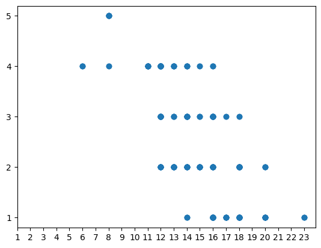

```python
# Create a figure and axes using subplots()
fig, ax = plt.subplots()

# Create a scatter plot of the 'EDUC' and 'SES' columns
scatter = ax.scatter(df['EDUC'], df['SES'])

# Set the x-axis and y-axis tick labels using the range from 1 to 23 and 1 to 5
plt.xticks(range(1, 24))
plt.yticks(range(1, 6))

# display the scatter plot
plt.show()
```

#### Visualization

Next I made some more graphs to get a better understanding of the data I am working with.  
I started by plotting how the SES is divided over the dataframe.

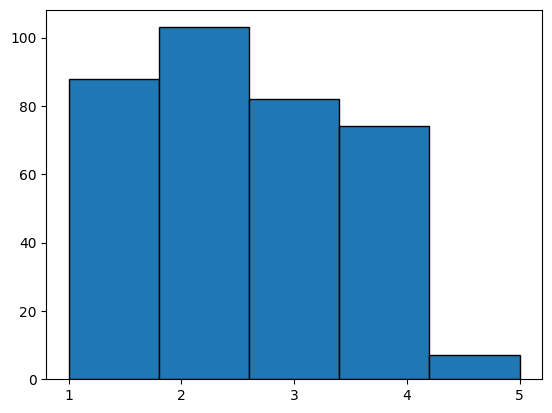

```python
plt.hist(df['SES'], bins=5, edgecolor='k')

# set the x-axis ticks to integers only
plt.xticks(range(1, 6))

# display the histogram
plt.show()
```

The spread is fairly equal except for the lowest status being less represented in this data set then the rest. And status 2 slightly peaking above the rest.

Besides this one I also made a graph to see what if there is a correlation between the group and the SES column.

[output not shown]

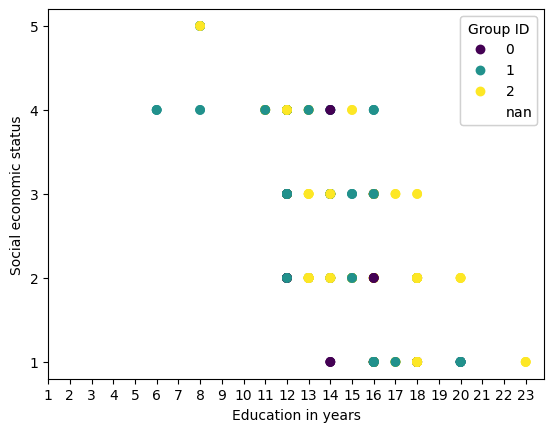

```python
# Create a figure and axes using subplots()
fig, ax = plt.subplots()

# Create a scatter plot of the 'EDUC' and 'SES' columns and set the color of the markers based on the
# 'Group ID' column
scatter = ax.scatter(df['EDUC'], df['SES'], c=df['Group ID'])
plt.xlabel('Education in years') #x label
plt.ylabel('Social economic status') #y label

# Set the x-axis and y-axis tick labels using the range from 1 to 23 and 1 to 5, respectively
plt.xticks(range(1, 24))
plt.yticks(range(1, 6))

# Create a legend for the scatter plot based on the unique values in the 'Group ID' column
legend1 = ax.legend(*scatter.legend_elements(),
                    loc="best", title="Group ID")

# Add the legend to the plot
ax.add_artist(legend1)

# Display the plot
plt.show()
```

To see if the years of education and the social economic status have an influence on dementia, I made a scatter-plot with group ID on the color.

0. converted
1. demented
2. non demented

I then made a heatmap to see what could be good features for my model.

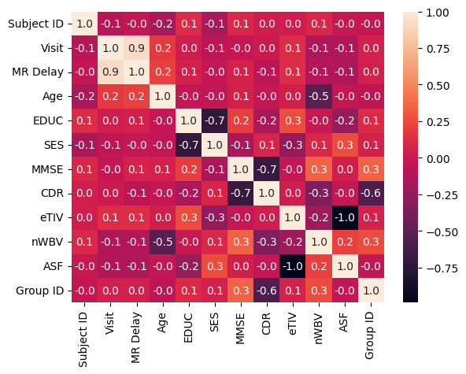

```python
correlations =df.corr()
plot = seaborn.heatmap(correlations, cbar=True, annot=True, fmt=".1f")
```

There is not a lot of corelation between my target variable and features in the dataset. CDR does have a high corelation but this is like choosing your target variable as a feature.

I also looked into any possible correlations between the group and SES columns. I looked into the distribution of the SES, the results being very evenly distributed except for the '5' (the lowest value) having a very low number of entries.

### Data preparation

Last iteration I stript the SubjectID from the MRI ID column. However I came to the conclusion that it was not only compiled from SubjectID but als so from the column visit. To prevent that there wil be a redundant column I decided to remove The entire MRI ID column.

```python
# Remove the 'MRI ID' column
df = df.drop('MRI ID', axis=1)
df
```

|  | Subject ID | Group | Visit | MR Delay | M/F | Hand | Age | EDUC | SES | MMSE | CDR | eTIV | nWBV | ASF | Group ID |
| --- | --- | --- | --- | --- | --- | --- | --- | --- | --- | --- | --- | --- | --- | --- | --- |
| 0 | 1 | Nondemented | 1 | 0 | M | R | 87 | 14 | 2.0 | 27.0 | 0.0 | 1987 | 0.696 | 0.883 | 2 |
| 1 | 1 | Nondemented | 2 | 457 | M | R | 88 | 14 | 2.0 | 30.0 | 0.0 | 2004 | 0.681 | 0.876 | 2 |
| 2 | 2 | Demented | 1 | 0 | M | R | 75 | 12 | NaN | 23.0 | 0.5 | 1678 | 0.736 | 1.046 | 1 |
| 3 | 2 | Demented | 2 | 560 | M | R | 76 | 12 | NaN | 28.0 | 0.5 | 1738 | 0.713 | 1.010 | 1 |
| 4 | 2 | Demented | 3 | 1895 | M | R | 80 | 12 | NaN | 22.0 | 0.5 | 1698 | 0.701 | 1.034 | 1 |
| ... | ... | ... | ... | ... | ... | ... | ... | ... | ... | ... | ... | ... | ... | ... | ... |
| 368 | 185 | Demented | 2 | 842 | M | R | 82 | 16 | 1.0 | 28.0 | 0.5 | 1693 | 0.694 | 1.037 | 1 |
| 369 | 185 | Demented | 3 | 2297 | M | R | 86 | 16 | 1.0 | 26.0 | 0.5 | 1688 | 0.675 | 1.040 | 1 |
| 370 | 186 | Nondemented | 1 | 0 | F | R | 61 | 13 | 2.0 | 30.0 | 0.0 | 1319 | 0.801 | 1.331 | 2 |
| 371 | 186 | Nondemented | 2 | 763 | F | R | 63 | 13 | 2.0 | 30.0 | 0.0 | 1327 | 0.796 | 1.323 | 2 |
| 372 | 186 | Nondemented | 3 | 1608 | F | R | 65 | 13 | 2.0 | 30.0 | 0.0 | 1333 | 0.801 | 1.317 | 2 |

373 rows × 15 columns

I also decided to remove the MR Delay because I will not be using the column and I can't find an exact meaning of the values. So far I only know that that it has something to fo with the injection of a substance to help with the MRI.

```python
# Remove the 'MR Delay' column
df = df.drop('MR Delay', axis=1)
df
```

|  | Subject ID | Group | Visit | M/F | Hand | Age | EDUC | SES | MMSE | CDR | eTIV | nWBV | ASF | Group ID |
| --- | --- | --- | --- | --- | --- | --- | --- | --- | --- | --- | --- | --- | --- | --- |
| 0 | 1 | Nondemented | 1 | M | R | 87 | 14 | 2.0 | 27.0 | 0.0 | 1987 | 0.696 | 0.883 | 2 |
| 1 | 1 | Nondemented | 2 | M | R | 88 | 14 | 2.0 | 30.0 | 0.0 | 2004 | 0.681 | 0.876 | 2 |
| 2 | 2 | Demented | 1 | M | R | 75 | 12 | NaN | 23.0 | 0.5 | 1678 | 0.736 | 1.046 | 1 |
| 3 | 2 | Demented | 2 | M | R | 76 | 12 | NaN | 28.0 | 0.5 | 1738 | 0.713 | 1.010 | 1 |
| 4 | 2 | Demented | 3 | M | R | 80 | 12 | NaN | 22.0 | 0.5 | 1698 | 0.701 | 1.034 | 1 |
| ... | ... | ... | ... | ... | ... | ... | ... | ... | ... | ... | ... | ... | ... | ... |
| 368 | 185 | Demented | 2 | M | R | 82 | 16 | 1.0 | 28.0 | 0.5 | 1693 | 0.694 | 1.037 | 1 |
| 369 | 185 | Demented | 3 | M | R | 86 | 16 | 1.0 | 26.0 | 0.5 | 1688 | 0.675 | 1.040 | 1 |
| 370 | 186 | Nondemented | 1 | F | R | 61 | 13 | 2.0 | 30.0 | 0.0 | 1319 | 0.801 | 1.331 | 2 |
| 371 | 186 | Nondemented | 2 | F | R | 63 | 13 | 2.0 | 30.0 | 0.0 | 1327 | 0.796 | 1.323 | 2 |
| 372 | 186 | Nondemented | 3 | F | R | 65 | 13 | 2.0 | 30.0 | 0.0 | 1333 | 0.801 | 1.317 | 2 |

373 rows × 14 columns

In this section I removed the MRI ID and MR Delay. The MRI ID is of no value because it is the result of the combination of two other columns, and the MR Delay contains no useful information for this project.

## Predictions Decision tree

I decided to change my approach from a classifier to a regressor model, because my target variable consists out of 3 groups which one of them is very closely related to the others. This makes it hard for a classification model to classify the data.

### Preprocessing Decision tree

Because the group ID is currently divided 1= demented 2 = nondemented and 0 converted I decided to change it so that it could be used for a regression model.

```python
# adding a new column called "Group ID" to the DataFrame. The values in this new column are derived from the "Group" column of df.
df["Group ID"] = df["Group"].map({"Nondemented":0, "Demented":1, "Converted": 0.5}).astype(float)
df
```

|  | Subject ID | Group | Visit | M/F | Hand | Age | EDUC | SES | MMSE | CDR | eTIV | nWBV | ASF | Group ID |
| --- | --- | --- | --- | --- | --- | --- | --- | --- | --- | --- | --- | --- | --- | --- |
| 0 | 1 | Nondemented | 1 | M | R | 87 | 14 | 2.0 | 27.0 | 0.0 | 1987 | 0.696 | 0.883 | 0.0 |
| 1 | 1 | Nondemented | 2 | M | R | 88 | 14 | 2.0 | 30.0 | 0.0 | 2004 | 0.681 | 0.876 | 0.0 |
| 2 | 2 | Demented | 1 | M | R | 75 | 12 | NaN | 23.0 | 0.5 | 1678 | 0.736 | 1.046 | 1.0 |
| 3 | 2 | Demented | 2 | M | R | 76 | 12 | NaN | 28.0 | 0.5 | 1738 | 0.713 | 1.010 | 1.0 |
| 4 | 2 | Demented | 3 | M | R | 80 | 12 | NaN | 22.0 | 0.5 | 1698 | 0.701 | 1.034 | 1.0 |
| ... | ... | ... | ... | ... | ... | ... | ... | ... | ... | ... | ... | ... | ... | ... |
| 368 | 185 | Demented | 2 | M | R | 82 | 16 | 1.0 | 28.0 | 0.5 | 1693 | 0.694 | 1.037 | 1.0 |
| 369 | 185 | Demented | 3 | M | R | 86 | 16 | 1.0 | 26.0 | 0.5 | 1688 | 0.675 | 1.040 | 1.0 |
| 370 | 186 | Nondemented | 1 | F | R | 61 | 13 | 2.0 | 30.0 | 0.0 | 1319 | 0.801 | 1.331 | 0.0 |
| 371 | 186 | Nondemented | 2 | F | R | 63 | 13 | 2.0 | 30.0 | 0.0 | 1327 | 0.796 | 1.323 | 0.0 |
| 372 | 186 | Nondemented | 3 | F | R | 65 | 13 | 2.0 | 30.0 | 0.0 | 1333 | 0.801 | 1.317 | 0.0 |

373 rows × 14 columns

I then decided re-print the heatmap to see if the correlation had changed.

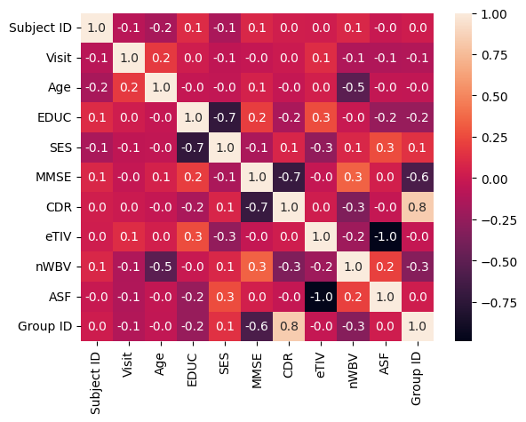

```python
# Calculate the correlation matrix for the dataframe
correlations = df.corr()

# Create a heatmap using seaborn library to visualize the correlation matrix
# Use cbar to include a colorbar, annot to display correlation values, and fmt to format them to one decimal place
plot = seaborn.heatmap(correlations, cbar=True, annot=True, fmt=".1f")
```

Because there are two NA value in the MMSE colum I decided to drop them so I can use them for a model.

```python
# dropping na since I have not yet found a good way to deal with them.
df1 = df.copy()
df1.dropna(inplace=True)
```

I am using the following features.

- MMSE-(mini mental state exam )
- nWBV -(Normalized whole brain volume)
- EDUC- (years of education)

because they have some correlation with the target variable.

I decided to not use the CDR -(Clinical dementia rating) because that would be almost the same as using my target variable as a feature.

```python
# define a list of features
features = ["MMSE","nWBV","EDUC"]

# define a list of target variable
target = "Group ID"

# create a DataFrame of input features
X = df1[features]

# create a Series of target variable
y = df1[target]
```

Splitting the train and test data so that I can use it for a decision tree model.

```python
# Import the train_test_split function from the model_selection module of scikit-learn
from sklearn.model_selection import train_test_split

# Split the data into training and testing sets with a test size of 20%
dtX_train, dtX_test, dty_train, dty_test = train_test_split(X, y, test_size=.2, random_state= 42)

# Print out the number of observations in the original dataset and the sizes of the training and testing sets
print("There are in total", len(X), "observations, of which", len(dtX_train), "are now in the train set, and", len(dtX_test), "in the test set.")
```

```
There are in total 354 observations, of which 283 are now in the train set, and 71 in the test set.
```

### Modeling Decision tree

I then fitted the train data to the decision tree model.

```python
# Import the DecisionTreeRegressor class from the tree module of scikit-learn
from sklearn.tree import DecisionTreeRegressor

# Create a new DecisionTreeRegressor model object
dtmodel = DecisionTreeRegressor()

# Fit the model to the training data
dtmodel.fit(dtX_train, dty_train)

# Calculate the R² score on the testing data and print it out
dtscore = dtmodel.score(dtX_test, dty_test)
print("R²:", dtscore)
```

```
R²: 0.29848345588235303
```

Then I made a bar plot to see how the features contribute to the model.

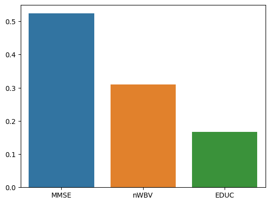

```python
# Plot the feature importances using a bar plot
plot = seaborn.barplot(y=dtmodel.feature_importances_, x=features)
```

As you can see each feature contributes to the outcome. How ever MMSE contributes the most.

I also plotted the tree to see what it does.

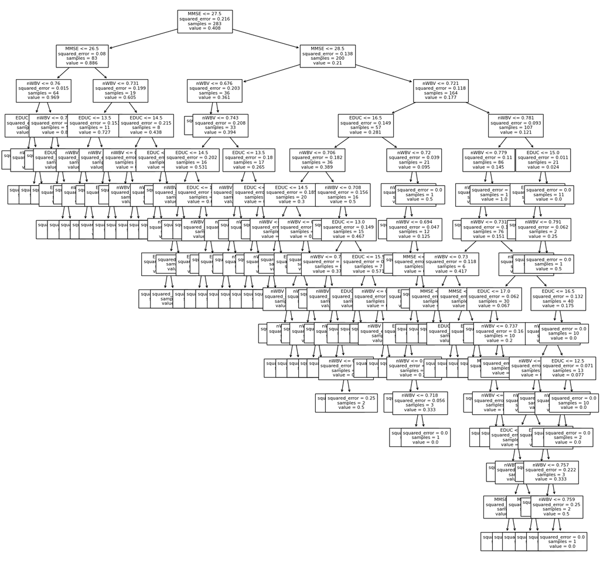

```python
# Import the necessary modules for data visualization
from sklearn.tree import plot_tree

# Set the size of the figure for the decision tree visualization
plt.figure(figsize=(18,18))

# Plot the decision tree using the plot_tree function and specify the font size, feature names, and class names
plot_tree(dtmodel, fontsize=8, feature_names=features, class_names=df['Group ID'])

# Display the decision tree
plt.show()
```

From this tree I can see that the model is extremely over-fitted. It keeps running until the very last sample has been group.

### Evaluation Decision tree

For the evaluation I printed the R² score of the test and train set, and the RMSE and the max error.

```python
# Calculate the R² score for the test and train sets
score = dtmodel.score(dtX_test, dty_test)
score_train = dtmodel.score(dtX_train, dty_train)

# Print the R² score for the test and train sets
print(f'R² test: {score}')
print(f'R² train: {score_train}')
```

```
R² test: 0.29848345588235303
R² train: 0.9631819364537859
```

The R2 score calculates the percentage of the target variable's variance that can be predicted from the independent variables. It can be anywhere between 0 and 1, where 0 means that the model explains no variability in the target variable and 1 means that it explains all variability.Because the difference between the R² test and R² train score I can see that this model is very over-fitted.

```python
# Import the required metrics for calculating error and RMSE
from sklearn.metrics import max_error
from sklearn.metrics import mean_squared_error


# Use the trained decision tree model to predict values for the test set
dtpred = dtmodel.predict(dtX_test)

# Calculate the maximum error and round it up
me = max_error(dty_test, dtpred)
me = math.ceil(me)
print(f"Max Error: {me}")

# Calculate the mean squared error and then take the square root to obtain RMSE
mse = mean_squared_error(dty_test, dtpred)
rmse = math.sqrt(mse)
rmse = math.ceil(rmse)
print(f"Root Mean Squared Error: {rmse}")
```

```
Max Error: 1
Root Mean Squared Error: 1
```

The maximum error is the largest difference between the predicted value and the actual target value in the test set. It represents the maximum deviation between the predicted and actual values.This is again a quite high value for my data frame. the largest difference is again the entire span of my dataset.

Because this tree is very over-fitted I wil try and make a less over-fitted tree with a grid-search to see if that will improve my model.

### Preprocessing Decision tree 2

Using a grid-search to find the best parameters for my decision tree.

```python
# Define a range of values for the hyperparameter
max_depth = [2, 5, 10, 15]
min_samples_split = [5,10,15, 20]
min_samples_leaf = [2,5,10,15]

# Create a dictionary of hyperparameters and their corresponding possible values
# This will be used as the parameter grid for hyperparameter tuning
param_grid = {
    'max_depth' : max_depth,
    'min_samples_split': min_samples_split,
    'min_samples_leaf': min_samples_leaf
}

from sklearn.model_selection import GridSearchCV

# Create an instance of the DecisionTreeRegressor class
dt = DecisionTreeRegressor()

# Create an instance of GridSearchCV to perform hyperparameter tuning
# Use the DecisionTreeRegressor instance, the parameter grid, and 5-fold cross-validation
dt_grid = GridSearchCV(dt, param_grid=param_grid, cv=5)

# Fit the GridSearchCV object to the training data
dt_grid.fit(dtX_train, dty_train)

# Retrieve the best hyperparameters found by GridSearchCV
dt_grid.best_params_
```

```
{'max_depth': 5, 'min_samples_leaf': 15, 'min_samples_split': 15}
```

### Modeling Decision tree 2

```python
# Import the DecisionTreeRegressor model from the sklearn.tree module
from sklearn.tree import DecisionTreeRegressor

# Create a DecisionTreeRegressor model with hyperparameters
dt2model = DecisionTreeRegressor(max_depth=5, min_samples_leaf=15, min_samples_split=5)

# Train the DecisionTreeRegressor model on the training data
dt2model.fit(dtX_train, dty_train)

# Evaluate the accuracy of the DecisionTreeRegressor model on the testing data
dt2score = dt2model.score(dtX_test, dty_test)

# Print the R² score of the model
print("R²:", dtscore)
```

```
R²: 0.29848345588235303
```

Made another bar chart to see how the features contribute to the model.

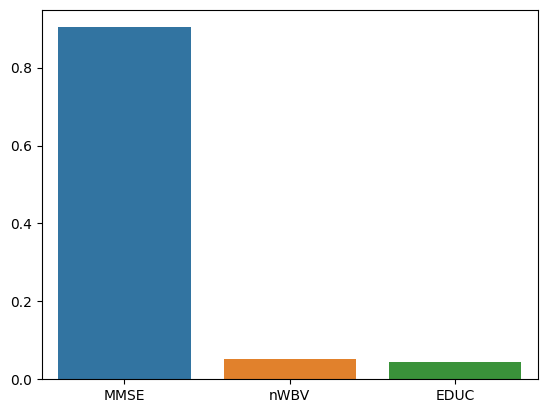

```python
# Plot the feature importances of the decision tree model using a bar plot
plot = seaborn.barplot(y=dt2model.feature_importances_, x=features)
```

Printed the tree to see how it comes to the decisions.

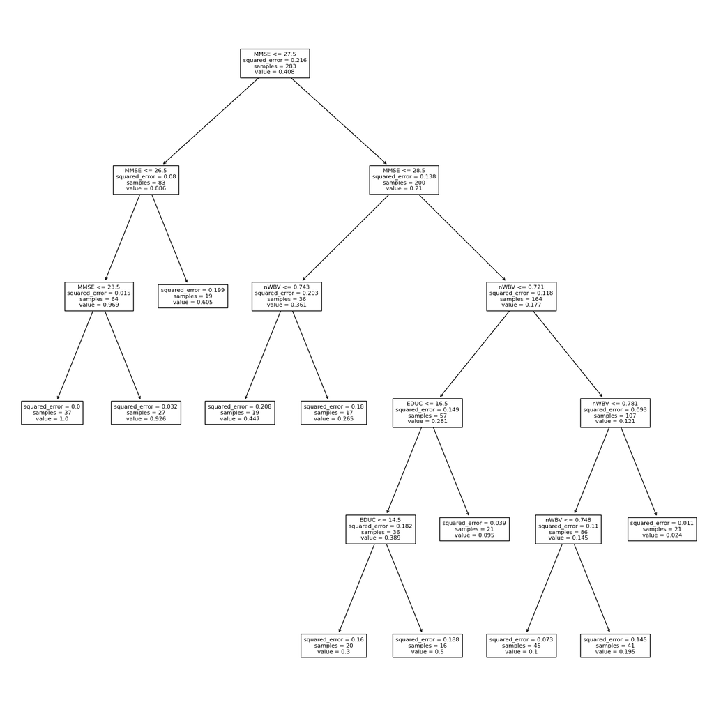

```python
# Set the figure size for the plot
plt.figure(figsize=(18,18))

# Import the plot_tree function from sklearn.tree
from sklearn.tree import plot_tree

# Plot the decision tree with specified parameters
plot_tree(dt2model, fontsize=8, feature_names=features, class_names=df['Group ID'])

# Display the plot
plt.show()
```

The tree looks less over-fitted as before, but does not mean it is not over-fitted. To see how the model preforms I made a more detailed evaluation.

### Evaluation Decision tree 2

For the evaluation I printed the R² score of the test and train set, and the RMSE and the max error.

```python
# Compute the R² score for the test and train sets using the decision tree model
score = dt2model.score(dtX_test, dty_test)
score_train = dt2model.score(dtX_train, dty_train)

# Print the R² scores for the test and train sets
print(f'R² test: {score}')
print(f'R² train: {score_train}')
```

```
R² test: 0.48940274141036855
R² train: 0.5396243001184022
```

The R2 score calculates the percentage of the target variable's variance that can be predicted from the independent variables. It can be anywhere between 0 and 1, where 0 means that the model explains no variability in the target variable and 1 means that it explains all variability. Since the R² score of the test and train set are closer to each other I can assume it is not as over-fitted. It still deviates 5% which means it is still somewhat over-fitted.

```python
# Import necessary modules for calculating regression metrics
from sklearn.metrics import max_error
from sklearn.metrics import mean_squared_error

# Make predictions using the trained decision tree model
dtpred = dt2model.predict(dtX_test)

# Calculate and print the maximum error
me = max_error(dty_test, dtpred)
me = math.ceil(me)
print(f"Max Error: {me}")

# Calculate and print the root mean squared error
mse = mean_squared_error(dty_test, dtpred)
rmse = math.sqrt(mse)
rmse = math.ceil(rmse)
print(f"Root Mean Squared Error: {rmse}")
```

```
Max Error: 1
Root Mean Squared Error: 1
```

The maximum error is the largest difference between the predicted value and the actual target value in the test set. It represents the maximum deviation between the predicted and actual values.This is again a quite high value for my data frame. the largest difference is again the entire span of my dataset.

This did not change at all compared to the last tree. I think this is because my Target variable has a very small span making it easy for the model to get to these high RMSE and Max Error values.

## Provisioning

### Data understanding

#### Anomalies

##### Missing values

So far I have dropped the Null values for all the columns because I did not know how to deal with them yet. here I wil go deeper in tot the null values of the MMSE column to see if I can fill them in or if dropping them is indeed the best way.

I stated by looking at the rows that have null values which were only two.

```python
# Select all rows in the 'df' dataframe where the 'MMSE' column is null
df[df.MMSE.isnull()]
```

|  | Subject ID | Group | Visit | M/F | Hand | Age | EDUC | SES | MMSE | CDR | eTIV | nWBV | ASF | Group ID |
| --- | --- | --- | --- | --- | --- | --- | --- | --- | --- | --- | --- | --- | --- | --- |
| 357 | 181 | Demented | 2 | F | R | 75 | 12 | NaN | NaN | 1.0 | 1169 | 0.742 | 1.501 | 1.0 |
| 358 | 181 | Demented | 3 | F | R | 77 | 12 | NaN | NaN | 1.0 | 1159 | 0.733 | 1.515 | 1.0 |

I can see that the two null values in the MMSE are from the same person.

```python
# Return a new DataFrame containing rows where the 'Subject ID' column matches one of the specified values
df[(df['Subject ID'] == 181)]
```

|  | Subject ID | Group | Visit | M/F | Hand | Age | EDUC | SES | MMSE | CDR | eTIV | nWBV | ASF | Group ID |
| --- | --- | --- | --- | --- | --- | --- | --- | --- | --- | --- | --- | --- | --- | --- |
| 356 | 181 | Demented | 1 | F | R | 74 | 12 | NaN | 26.0 | 0.5 | 1171 | 0.733 | 1.499 | 1.0 |
| 357 | 181 | Demented | 2 | F | R | 75 | 12 | NaN | NaN | 1.0 | 1169 | 0.742 | 1.501 | 1.0 |
| 358 | 181 | Demented | 3 | F | R | 77 | 12 | NaN | NaN | 1.0 | 1159 | 0.733 | 1.515 | 1.0 |

Person 181 has before done the MMSE and gotten a score of 26. The last 2 visits he did not get a score. I am gonna use the first values to fil down for the missing values. I am gonna assume that it has not changed.

Next I made a couple of graphs to see if I can find a way to fill in the missing values. I also separated the groups so I can more easily make the graphs.

```python
# Create new dataframes containing only observations with specific group types
dfconverted = df[(df['Group'] == 'Converted')]
dfdemented = df[(df['Group'] == 'Demented')]
dfnot = df[(df['Group'] == 'Nondemented')]
```

First I am going to look at the SES column again.

```python
# Select all rows in the 'df' dataframe where the 'SES' column is null
df[df.SES.isnull()]
```

|  | Subject ID | Group | Visit | M/F | Hand | Age | EDUC | SES | MMSE | CDR | eTIV | nWBV | ASF | Group ID |
| --- | --- | --- | --- | --- | --- | --- | --- | --- | --- | --- | --- | --- | --- | --- |
| 2 | 2 | Demented | 1 | M | R | 75 | 12 | NaN | 23.0 | 0.5 | 1678 | 0.736 | 1.046 | 1.0 |
| 3 | 2 | Demented | 2 | M | R | 76 | 12 | NaN | 28.0 | 0.5 | 1738 | 0.713 | 1.010 | 1.0 |
| 4 | 2 | Demented | 3 | M | R | 80 | 12 | NaN | 22.0 | 0.5 | 1698 | 0.701 | 1.034 | 1.0 |
| 10 | 7 | Demented | 1 | M | R | 71 | 16 | NaN | 28.0 | 0.5 | 1357 | 0.748 | 1.293 | 1.0 |
| 11 | 7 | Demented | 3 | M | R | 73 | 16 | NaN | 27.0 | 1.0 | 1365 | 0.727 | 1.286 | 1.0 |
| 12 | 7 | Demented | 4 | M | R | 75 | 16 | NaN | 27.0 | 1.0 | 1372 | 0.710 | 1.279 | 1.0 |
| 134 | 63 | Demented | 1 | F | R | 80 | 12 | NaN | 30.0 | 0.5 | 1430 | 0.737 | 1.228 | 1.0 |
| 135 | 63 | Demented | 2 | F | R | 81 | 12 | NaN | 27.0 | 0.5 | 1453 | 0.721 | 1.208 | 1.0 |
| 207 | 99 | Demented | 1 | F | R | 80 | 12 | NaN | 27.0 | 0.5 | 1475 | 0.762 | 1.190 | 1.0 |
| 208 | 99 | Demented | 2 | F | R | 83 | 12 | NaN | 23.0 | 0.5 | 1484 | 0.750 | 1.183 | 1.0 |
| 237 | 114 | Demented | 1 | F | R | 76 | 12 | NaN | 27.0 | 0.5 | 1316 | 0.727 | 1.333 | 1.0 |
| 238 | 114 | Demented | 2 | F | R | 78 | 12 | NaN | 27.0 | 1.0 | 1309 | 0.709 | 1.341 | 1.0 |
| 322 | 160 | Demented | 1 | M | R | 76 | 12 | NaN | 27.0 | 0.5 | 1557 | 0.705 | 1.127 | 1.0 |
| 323 | 160 | Demented | 2 | M | R | 78 | 12 | NaN | 29.0 | 1.0 | 1569 | 0.704 | 1.119 | 1.0 |
| 356 | 181 | Demented | 1 | F | R | 74 | 12 | NaN | 26.0 | 0.5 | 1171 | 0.733 | 1.499 | 1.0 |
| 357 | 181 | Demented | 2 | F | R | 75 | 12 | NaN | NaN | 1.0 | 1169 | 0.742 | 1.501 | 1.0 |
| 358 | 181 | Demented | 3 | F | R | 77 | 12 | NaN | NaN | 1.0 | 1159 | 0.733 | 1.515 | 1.0 |
| 359 | 182 | Demented | 1 | M | R | 73 | 12 | NaN | 23.0 | 0.5 | 1661 | 0.698 | 1.056 | 1.0 |
| 360 | 182 | Demented | 2 | M | R | 75 | 12 | NaN | 20.0 | 0.5 | 1654 | 0.696 | 1.061 | 1.0 |

As I stated in the previous iteration there are 8 different persons will null value in this column all of them have not stated their Social Economical Status before. I was not able to find a way to fill it with the EDUC variable. So I thought maybe I can fill it based on the group they were in.

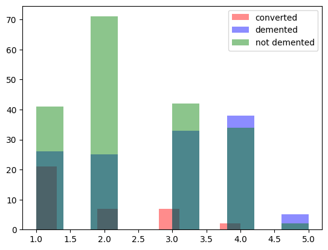

```python
# plotting two histograms on the same axis
# plot histogram of SES values in dfconverted, with transparency and color red
plt.hist(dfconverted['SES'] , alpha = 0.45,color='red')
# plot histogram of SES values in dfdemented, with transparency and color blue
plt.hist(dfdemented['SES'] , alpha = 0.45, color='blue')
# plot histogram of SES values in dfnot, with transparency and color green
plt.hist(dfnot['SES'], alpha = 0.45, color='green')

# add a legend with labels for each histogram
plt.legend(['converted', 'demented', 'not demented'])
```

This does not give me any significant information on how to deal with the missing values in the SES columns.

This also shows me that the social economical status does not really have a effect on whether someone is demented or not. The levels of the demented not demented and converted are really all over teh place and there is not really something that says the hight of the status the lower the chance, it only goes down a little bit.

That is the reason I choose to not use my SES column in my model. There for I will also not do anything to deal with the missing values.

I made this graph to make sure I have a graph that I can check when I filled the NaN in the MMSE columns.

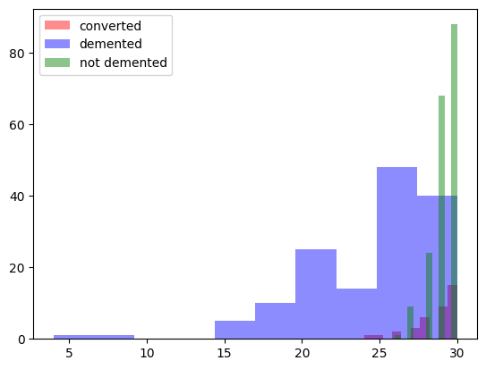

```python
# plotting two histograms on the same axis
# plot histogram of MMSE values in dfconverted, with transparency and color red
plt.hist(dfconverted['MMSE'] , alpha = 0.45,color='red')
# plot histogram of MMSE values in dfdemented, with transparency and color blue
plt.hist(dfdemented['MMSE'] , alpha = 0.45, color='blue')
# plot histogram of MMSE values in dfnot, with transparency and color green
plt.hist(dfnot['MMSE'], alpha = 0.45, color='green')


# add a legend with labels for each histogram
plt.legend(['converted',
            'demented',
            'not demented'])
```

#### Visualization

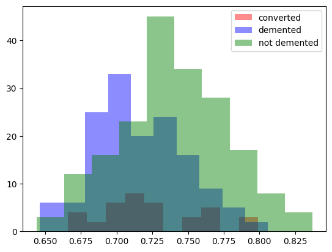

```python
# plotting two histograms on the same axis
# plot histogram of nWBV values in dfconverted, with transparency and color red
plt.hist(dfconverted['nWBV'] , alpha = 0.45,color='red')
# plot histogram of nWBV values in dfdemented, with transparency and color blue
plt.hist(dfdemented['nWBV'] , alpha = 0.45, color='blue')
# plot histogram of nWBV values in dfnot, with transparency and color green
plt.hist(dfnot['nWBV'], alpha = 0.45, color='green')

# add a legend with labels for each histogram
plt.legend(['converted',
            'demented',
            'not demented'])
```

Interesting here is to see that the demented patients skew the opposite from the not demented patients. Although the group with demented patients is more left skewed then the non demented patient are right skewed.

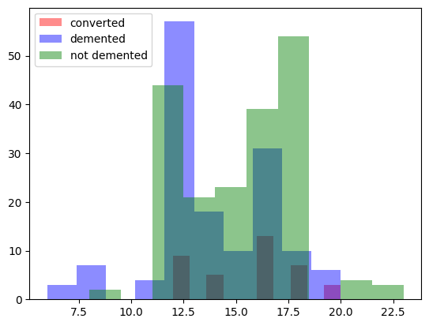

```python
# plotting two histograms on the same axis
# plot histogram of EDUC values in dfconverted, with transparency and color red
plt.hist(dfconverted['EDUC'] , alpha = 0.45,color='red')
# plot histogram of nWBV values in dfdemented, with transparency and color blue
plt.hist(dfdemented['EDUC'] , alpha = 0.45, color='blue')
# plot histogram of nWBV values in dfnot, with transparency and color green
plt.hist(dfnot['EDUC'], alpha = 0.45, color='green')


# add a legend with labels for each histogram
plt.legend(['converted',
            'demented',
            'not demented'])
```

Interesting here is to see that group of demented patients are grouped more on the left so lower(lesser years of education) education and the non demented patient are more grouped on the right so higher (more years of education)education

In conclusion, what I did here is find a way to fill in the missing values in the MMSE column. This was done by copying the value assigned to this patient in a previous session in the missing places.

I also decided what to do with the missing values in the SES column. After a thorough review of the values in this column and their relevance to this project I concluded that they had no value, and thus the column will be dropped. Removing the need to handle the missing values in the first place.

### Data preparation

Filling the value for patient 181 with the same value as they had on the first visit.

```python
# Fill missing values in the 'MMSE' column with 26.0
df['MMSE'] = df['MMSE'].fillna(26.0)
```

I printed subject 181 again to see if the NAN were filled in correctly.

```python
# Return a new DataFrame containing rows where the 'Subject ID' column matches one of the specified values
df[(df['Subject ID'] == 181)]
```

|  | Subject ID | Group | Visit | M/F | Hand | Age | EDUC | SES | MMSE | CDR | eTIV | nWBV | ASF | Group ID |
| --- | --- | --- | --- | --- | --- | --- | --- | --- | --- | --- | --- | --- | --- | --- |
| 356 | 181 | Demented | 1 | F | R | 74 | 12 | NaN | 26.0 | 0.5 | 1171 | 0.733 | 1.499 | 1.0 |
| 357 | 181 | Demented | 2 | F | R | 75 | 12 | NaN | 26.0 | 1.0 | 1169 | 0.742 | 1.501 | 1.0 |
| 358 | 181 | Demented | 3 | F | R | 77 | 12 | NaN | 26.0 | 1.0 | 1159 | 0.733 | 1.515 | 1.0 |

I plotted the histogram of the MMSE again to see if the ballance of the data changed.

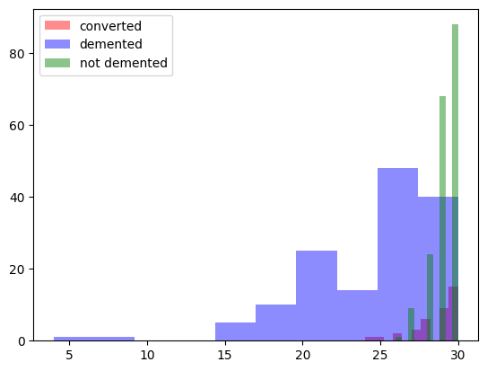

```python
# plotting two histograms on the same axis
# plot histogram of MMSE values in dfconverted, with transparency and color red
plt.hist(dfconverted['MMSE'] , alpha = 0.45,color='red')
# plot histogram of MMSE values in dfdemented, with transparency and color blue
plt.hist(dfdemented['MMSE'] , alpha = 0.45, color='blue')
# plot histogram of MMSE values in dfnot, with transparency and color green
plt.hist(dfnot['MMSE'], alpha = 0.45, color='green')



# add a legend with labels for each histogram
plt.legend(['converted',
            'demented',
            'not demented'])

plt.show()
```

In conclusion after fixing the missing values, no noticeable issues where detected. That is what I expected since it was only 2 missing values of the 373 values.

## Predictions Random forest

Since The decision tree was not preforming as well as I would have expected and is still trying to over-fit I decided to try a random forest regressor.

That is because a random forest regressor is not as prone to over-fitting as the decision tree. They also tend to have a higher accuracy for the prediction.

### Preprocessing Random forest

I am using the following features.

- MMSE-(mini mental state exam )
- nWBV -(Normalized whole brain volume)
- EDUC- (years of education)

because they have some correlation with the target variable.

I decided to not use the CDR -(Clinical dementia rating) because that would be almost the same as using my target variable as a feature.

```python
# Define the features and target variable for our model
features = ["MMSE","nWBV","EDUC"]
target = "Group ID"

# Create the feature matrix X and target vector y using the defined features and target variable from the df1 DataFrame
X = df1[features]
y = df1[target]
```

Splitting the train and test data so that I can use it for a decision tree model.

```python
# Import the train_test_split function from sklearn.model_selection
from sklearn.model_selection import train_test_split

# Split the data into training and test sets using a 80:20 split
rfX_train, rfX_test, rfy_train, rfy_test = train_test_split(X, y, test_size=.2, random_state= 42)

# Print the number of observations in the original dataset, training set, and test set
print("There are in total", len(X), "observations, of which", len(rfX_train), "are now in the train set, and", len(rfX_test), "in the test set.")
```

```
There are in total 354 observations, of which 283 are now in the train set, and 71 in the test set.
```

### Modeling Random forest

I then fitted the train data to the random forest model.

```python
# Import the RandomForestRegressor class from the ensemble module of scikit-learn
from sklearn.ensemble import RandomForestRegressor

# Create a new RandomForestRegressor model object
rfmodel = RandomForestRegressor()

# Fit the model to the training data
rfmodel.fit(rfX_train, rfy_train)

# Calculate the R² score on the testing data and print it out
rfscore = rfmodel.score(rfX_test, rfy_test)
print("R²:", rfscore)
```

```
R²: 0.4413532906262766
```

Then I made a bar plot to see how the features contribute to the model.

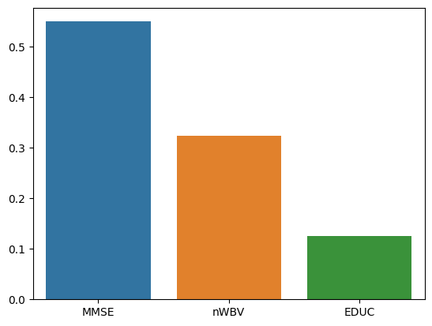

```python
# Create a bar plot using seaborn
# - y: the feature importances obtained from the Random Forest model
# - x: the names of the features
plot = seaborn.barplot(y=rfmodel.feature_importances_, x=features)
```

As you can see each feature contributes to the outcome. How ever MMSE contributes the most.

### Evaluation Random forest

For the evaluation I printed the R² score of the test and train set, and the RMSE and the max error.

```python
# Calculate the R² score on the testing data
score = rfmodel.score(rfX_test, rfy_test)

# Calculate the R² score on the training data
score_train = rfmodel.score(rfX_train, rfy_train)

# Print out the R² score on the testing data
print(f'R² test: {score}')

# Print out the R² score on the training data
print(f'R² train: {score_train}')
```

```
R² test: 0.4413532906262766
R² train: 0.8942924307578665
```

The R2 score calculates the percentage of the target variable's variance that can be predicted from the independent variables. It can be anywhere between 0 and 1, where 0 means that the model explains no variability in the target variable and 1 means that it explains all variability. The difference between the R² test and R² train tells me that the model is very over-fitted.

```python
from sklearn.metrics import max_error
from sklearn.metrics import mean_squared_error

# Make predictions using the random forest model on the test set
rfpred = rfmodel.predict(rfX_test)

# Calculate the maximum error between the true and predicted values
me = max_error(rfy_test, rfpred)
me = math.ceil(me)
print(f"Max Error: {me}")

# Calculate the root mean squared error between the true and predicted values
mse = mean_squared_error(rfy_test, rfpred)
rmse = math.sqrt(mse)
rmse = math.ceil(rmse)
print(f"Root Mean Squared Error: {rmse}")
```

```
Max Error: 1
Root Mean Squared Error: 1
```

The maximum error is the largest difference between the predicted value and the actual target value in the test set. It represents the maximum deviation between the predicted and actual values.This is again a quite high value for my data frame. the largest difference is again the entire span of my dataset.

This did not change at all compared to the last 2 models. I am pretty sure this is because my Target variable has a very small span making it easy for the model to get to these high RMSE and Max Error values.

Because this tree is very over-fitted I wil try and make a less over-fitted tree with a grid-search to see if that will improve my model.

### Preprocessing Random forest 2

Using a grid-search to find the best parameters for my random forest regressor.

```python
# Define a range of values for the hyperparameter
max_depth = [5, 10, 15]
min_samples_split = [30, 45, 50, 55, 65]
min_samples_leaf = [2,5,10,15]

# Create a dictionary of hyperparameters and their corresponding possible values
# This will be used as the parameter grid for hyperparameter tuning
param_grid = {
    'max_depth' : max_depth,
    'min_samples_split': min_samples_split,
    'min_samples_leaf': min_samples_leaf
}

from sklearn.model_selection import GridSearchCV

# Create an instance of the DecisionTreeRegressor class
rf = RandomForestRegressor()

# Create an instance of GridSearchCV to perform hyperparameter tuning
# Use the DecisionTreeRegressor instance, the parameter grid, and 5-fold cross-validation
rf_grid = GridSearchCV(rf, param_grid=param_grid, cv=5)

# Fit the GridSearchCV object to the training data
rf_grid.fit(rfX_train, rfy_train)

# Retrieve the best hyperparameters found by GridSearchCV
rf_grid.best_params_
```

```
{'max_depth': 10, 'min_samples_leaf': 2, 'min_samples_split': 30}
```

### Modeling Random forest 2

I then fitted the train data to the random forest model using the parameters that the grid search gave me.

```python
# Import the RandomForestRegressor class from the sklearn.ensemble module
from sklearn.ensemble import RandomForestRegressor

# Instantiate a RandomForestRegressor object with specified hyperparameters
rf2model = RandomForestRegressor(max_depth=10, min_samples_leaf=2, min_samples_split=30)

# Train the model on the training set
rf2model.fit(rfX_train, rfy_train)

# Compute the R² score of the model on the test set
rfscore = rf2model.score(rfX_test, rfy_test)

# Print the R² score
print("R²:", rfscore)
```

```
R²: 0.536757831970506
```

Made another bar chart to see how the features contribute to the model.

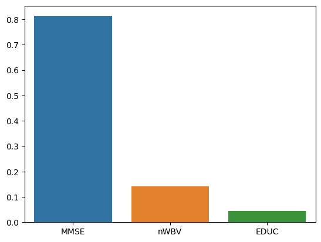

```python
# Create a bar plot of feature importances using the seaborn library
# Set the y-axis values to the feature importances from the random forest model
# Set the x-axis values to the feature names
plot = seaborn.barplot(y=rf2model.feature_importances_, x=features)
```

Unlike the last random forest the nWBV anf EDUC features now barely contribute to the models prediction. I saw the same thing happening with the decision tree models. The features just do not have that much corelation with my target variable as you can see in the correlations heatmap printed below.

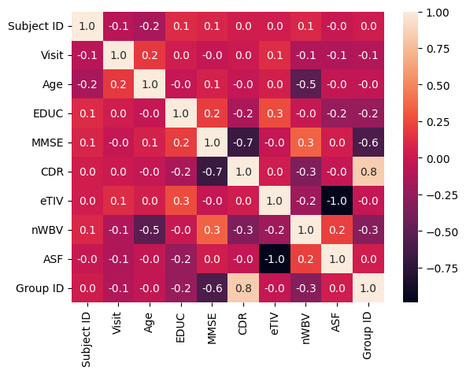

```python
# Calculate the correlation matrix for the dataframe
correlations = df.corr()

# Create a heatmap using seaborn library to visualize the correlation matrix
# Use cbar to include a colorbar, annot to display correlation values, and fmt to format them to one decimal place
plot = seaborn.heatmap(correlations, cbar=True, annot=True, fmt=".1f")
```

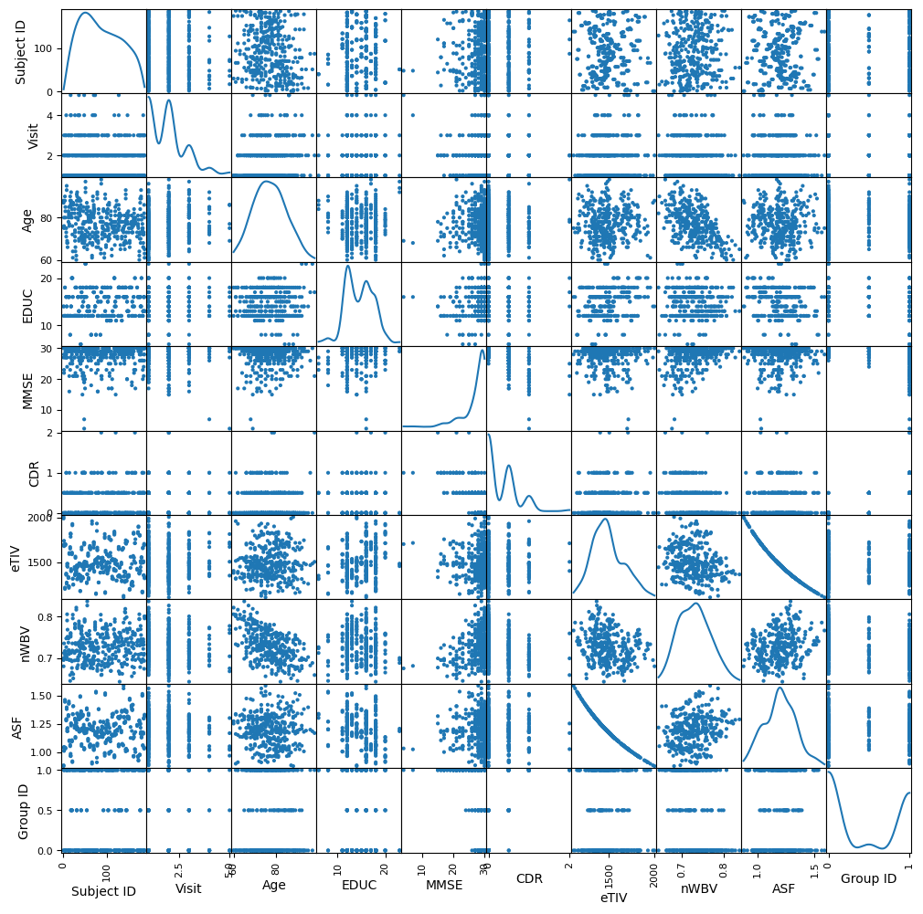

```python
from pandas.plotting import scatter_matrix
scatter_matrix(df, alpha=1, figsize=(12, 12), diagonal='kde');
```

As you can see in this scatter matrix there aren't any features with really good corelation.

### Evaluation Random forest 2

For the evaluation I printed the R² score of the test and train set, and the RMSE and the max error.

```python
# Calculate the R² score on the testing data and print it out
score = rf2model.score(rfX_test, rfy_test)
print(f'R² test: {score}')

# Calculate the R² score on the training data and print it out
score_train = rf2model.score(rfX_train, rfy_train)
print(f'R² train: {score_train}')
```

```
R² test: 0.536757831970506
R² train: 0.5900354898430267
```

```python
# Import necessary metrics from scikit-learn
from sklearn.metrics import max_error
from sklearn.metrics import mean_squared_error

# Predict using the random forest model
rf2pred = rf2model.predict(rfX_test)

# Calculate and print the maximum error
me = max_error(rfy_test, rf2pred)
me = math.ceil(me)
print(f"Max Error: {me}")

# Calculate and print the root mean squared error
mse = mean_squared_error(rfy_test, rf2pred)
rmse = math.sqrt(mse)
rmse = math.ceil(rmse)
print(f"Root Mean Squared Error: {rmse}")
```

```
Max Error: 1
Root Mean Squared Error: 1
```

The maximum error is the largest difference between the predicted value and the actual target value in the test set. It represents the maximum deviation between the predicted and actual values.This is again a quite high value for my data frame. the largest difference is again the entire span of my dataset.

By now I already know this is pretty much not changing no matter what parameters I use.

### Conclusion

So far, the KNN model had the best accuracy with about (70%) but was not performing that well since one of the groups in my target variable resembled the other too. This is why it played heads and tails with the data rather than accurately predicting the correct groups.

So I then tried to use a regression model for the data.

That's when I decide to try a random forest regressor. Which gave me a higher accuracy but was still over-fitting. So I also performed a grid search here to find the best parameter for the random forest regressor. This gave me a less over-fitted model with a higher accuracy of about (50%)

In conclusion, I think with the data that I currently I can not make a reliable enough model to use for real case scenarios. It does not have the needed data to get an accurate enough model to indicate is someone has dementia.